# Rabbit_PFAS_TK_and_TTC_and_data_summary

Andrew East

2024-10-05

```r
library(tidyverse)
rabbita <- read_csv("Rabbit_thirdsend_stacked_data_15SEP2023.csv")
library(knitr)
library(ggpubr)
library(minpack.lm)
library(nlstools)
library(broom)
library(nls.multstart)

###! Tread Carefully Here !##
options(dplyr.summarise.inform=F)
### This turns off the tidyverse summarize/summarise messages indicating default grouping patterns in resultant tibbles ##
### If you don't know what this means, check out https://stackoverflow.com/questions/62140483/how-to-interpret-dplyr-message-summarise-regrouping-output-by-x-override
### Implications of this being false are unknown errors and impacts in other activities in this R session that you may not detect without these messages!
```

```r
rabbit <- rabbita |>
  pivot_longer(c(kidney, liver, muscle), names_to="tissue", values_to="concentration") # tissues are in wide format

rabbit <- rabbit |>
  group_by(PFAS, tissue) |>
  mutate(minconc=min(concentration[concentration!=0])) # identify the PFAS+tissue-wise non-zero minimum concentration (zeros are put in for non-detects...)

rabbit <- rabbit |>
  mutate(conc3=case_when(
    concentration==0&timemod==0~minconc,          # on the starting timepoint, set non-detects to minimum concentration to ensure regressions have starting point
    concentration==0&timemod>=1~as.numeric(NA),   # for other timepoints, set non-detects to NA to they are approriately excluded from regressions
    T~concentration                               # all other data leave
  ))

rabbit$depday <- rabbit$timemod-28                                              #add depuration day
rabbit$dietperiod <- ifelse(rabbit$timemod>=29, "elimination","uptake")         #code for uptake or elimination data (not used)
rabbit$sex <- factor(ifelse(str_detect(rabbit$rabbitID,"F"),"Female","Male"))   #code for sex


rabbit <- rabbit %>%
  group_by(PFAS,time) %>%
  mutate(meandietconc=mean(dietconcentration))    #add PFAS+time-wise mean concentration (mean of groups' diets)

rabbit <- rabbit |>
  filter(!(PFAS=="PFOS"&group==1)) # PFOS group 1 LOQ is 1000 ng/L, while others in that groups are 0.5, 1,2,5,10,20. Reporting limits are 10-100-fold above others accordingly high rate of non-detects is non-sensical and strategies to manage non-detects are inappropriate

rabbit <- rabbit|> ungroup()       # set dataset back to ungrouped tibble
```

```r
rabbit |>
  filter(timemod==56&PFAS=="PFOS")|>
  dplyr::select(rabbitID, tissue,conc3) |>
  arrange(tissue,rabbitID) |>
  kable(caption="RF61 muscle PFOS is 100-fold above other samples collected on day 56")
```

RF61 muscle PFOS is 100-fold above other samples collected on day 56

| rabbitID | tissue | conc3 |
| --- | --- | --- |
| RF39 | kidney | 396.53 |
| RF61 | kidney | 83.56 |
| RM29 | kidney | 652.47 |
| RM48 | kidney | 43.29 |
| RF39 | liver | 105.40 |
| RF61 | liver | 51.54 |
| RM29 | liver | 130.46 |
| RM48 | liver | 58.19 |
| RF39 | muscle | 2.14 |
| RF61 | muscle | 161.01 |
| RM29 | muscle | 6.27 |
| RM48 | muscle | 1.77 |

```r
rabbit <- rabbit |>
  filter(rabbitID!="RF61")
```

# Summary of data

## Diet summary

```r
dietsumm <- rabbit |>
  group_by(group, PFAS, timemod) |>
  summarize(
    dietconcentration=first(dietconcentration)
  )

dietsummbyperiodG <- rabbit |>
  group_by(group, PFAS, dietperiod) |>
  summarize(
    countdays=length(unique(timemod)),
    mean=mean(dietconcentration),
    median=median(dietconcentration, na.rm=T),
    sd=sd(dietconcentration, na.rm=T),
    sem=sd/sqrt(countdays),
    perc_cv=(sd/mean)*100,
    upper=quantile(dietconcentration, probs=c(0.975), names=F, na.rm=T),
    lower=quantile(dietconcentration, probs=c(0.025), names=F, na.rm=T)
  ) |>
  arrange(PFAS, desc(dietperiod))

kable(dietsummbyperiodG, caption="summary of diets by uptake and elimination and groups")
```

summary of diets by uptake and elimination and groups

| group | PFAS | dietperiod | countdays | mean | median | sd | sem | perc_cv | upper | lower |
| --- | --- | --- | --- | --- | --- | --- | --- | --- | --- | --- |
| 1 | 8:2 FTS | uptake | 5 | 51.0000000 | 18.500 | 60.5118454 | 27.0617199 | 118.650677 | 134.50 | 0.00 |
| 2 | 8:2 FTS | uptake | 5 | 7.2916667 | 4.680 | 9.1760167 | 4.1036394 | 125.842515 | 26.55 | 0.00 |
| 3 | 8:2 FTS | uptake | 5 | 2.6533333 | 3.530 | 1.9444661 | 0.8695917 | 73.283900 | 4.68 | 0.00 |
| 1 | 8:2 FTS | elimination | 4 | 48.9842857 | 0.310 | 57.7757148 | 28.8878574 | 117.947448 | 114.09 | 0.00 |
| 2 | 8:2 FTS | elimination | 4 | 0.0000000 | 0.000 | 0.0000000 | 0.0000000 | NaN | 0.00 | 0.00 |
| 3 | 8:2 FTS | elimination | 4 | 0.0000000 | 0.000 | 0.0000000 | 0.0000000 | NaN | 0.00 | 0.00 |
| 1 | PFBA | uptake | 5 | 592.1666667 | 780.500 | 443.0365673 | 198.1319762 | 74.816195 | 1109.00 | 0.00 |
| 2 | PFBA | uptake | 5 | 234.9016667 | 324.685 | 171.6063394 | 76.7446880 | 73.054543 | 402.12 | 0.00 |
| 3 | PFBA | uptake | 5 | 107.0183333 | 141.865 | 81.1535982 | 36.2929924 | 75.831491 | 215.69 | 0.00 |
| 1 | PFBA | elimination | 4 | 8.6700000 | 6.190 | 4.5026188 | 2.2513094 | 51.933320 | 14.82 | 5.00 |
| 2 | PFBA | elimination | 4 | 12.4250000 | 13.020 | 2.1949884 | 1.0974942 | 17.665902 | 14.75 | 8.91 |
| 3 | PFBA | elimination | 4 | 3.2462500 | 3.330 | 1.2730170 | 0.6365085 | 39.215002 | 6.19 | 1.84 |
| 1 | PFBS | uptake | 5 | 165.8333333 | 238.500 | 119.2309883 | 53.3217190 | 71.898083 | 259.00 | 0.00 |
| 2 | PFBS | uptake | 5 | 71.7883333 | 84.190 | 61.4838977 | 27.4964349 | 85.646086 | 177.99 | 0.00 |
| 3 | PFBS | uptake | 5 | 18.7950000 | 25.695 | 13.7926449 | 6.1682583 | 73.384650 | 33.31 | 0.00 |
| 1 | PFBS | elimination | 4 | 1.8885714 | 0.960 | 2.1652605 | 1.0826302 | 114.650705 | 5.17 | 0.00 |
| 2 | PFBS | elimination | 4 | 1.0950000 | 1.390 | 0.5279081 | 0.2639540 | 48.210785 | 1.40 | 0.20 |
| 3 | PFBS | elimination | 4 | 0.1414286 | 0.190 | 0.0627922 | 0.0313961 | 44.398507 | 0.19 | 0.05 |
| 1 | PFHpA | uptake | 5 | 22.6666667 | 32.000 | 16.4438438 | 7.3539105 | 72.546370 | 37.00 | 0.00 |
| 2 | PFHpA | uptake | 5 | 16.7133333 | 10.510 | 22.0309032 | 9.8525194 | 131.816334 | 63.56 | 0.00 |
| 3 | PFHpA | uptake | 5 | 5.8350000 | 7.880 | 4.2846160 | 1.9161385 | 73.429580 | 10.60 | 0.00 |
| 1 | PFHpA | elimination | 4 | 0.2285714 | 0.000 | 0.3703280 | 0.1851640 | 162.018518 | 0.80 | 0.00 |
| 2 | PFHpA | elimination | 4 | 2.2725000 | 2.480 | 0.3792928 | 0.1896464 | 16.690553 | 2.50 | 1.63 |
| 3 | PFHpA | elimination | 4 | 0.0342857 | 0.060 | 0.0304256 | 0.0152128 | 88.741197 | 0.06 | 0.00 |
| 1 | PFHpS | uptake | 5 | 22.6666667 | 32.000 | 16.4438438 | 7.3539105 | 72.546370 | 37.00 | 0.00 |
| 2 | PFHpS | uptake | 5 | 16.7133333 | 10.510 | 22.0309032 | 9.8525194 | 131.816334 | 63.56 | 0.00 |
| 3 | PFHpS | uptake | 5 | 5.8350000 | 7.880 | 4.2846160 | 1.9161385 | 73.429580 | 10.60 | 0.00 |
| 1 | PFHpS | elimination | 4 | 0.2285714 | 0.000 | 0.3703280 | 0.1851640 | 162.018518 | 0.80 | 0.00 |
| 2 | PFHpS | elimination | 4 | 2.2725000 | 2.480 | 0.3792928 | 0.1896464 | 16.690553 | 2.50 | 1.63 |
| 3 | PFHpS | elimination | 4 | 0.0342857 | 0.060 | 0.0304256 | 0.0152128 | 88.741197 | 0.06 | 0.00 |
| 1 | PFHxA | uptake | 5 | 111.3283333 | 151.970 | 80.8821406 | 36.1715929 | 72.651892 | 188.20 | 0.00 |
| 2 | PFHxA | uptake | 5 | 68.8483333 | 51.530 | 66.4275253 | 29.7072924 | 96.483854 | 175.15 | 0.00 |
| 3 | PFHxA | uptake | 5 | 7.9866667 | 10.360 | 5.9222959 | 2.6485312 | 74.152286 | 13.60 | 0.00 |
| 1 | PFHxA | elimination | 4 | 2.3557143 | 1.780 | 1.4038895 | 0.7019447 | 59.595067 | 4.50 | 1.31 |
| 2 | PFHxA | elimination | 4 | 1.7450000 | 1.840 | 0.2640652 | 0.1320326 | 15.132677 | 1.99 | 1.31 |
| 3 | PFHxA | elimination | 4 | 0.2000000 | 0.260 | 0.0909945 | 0.0454973 | 45.497253 | 0.26 | 0.00 |
| 1 | PFHxS | uptake | 5 | 43.2500000 | 58.700 | 32.1056871 | 14.3580998 | 74.232803 | 82.20 | 0.00 |
| 2 | PFHxS | uptake | 5 | 27.7766667 | 14.940 | 39.0654052 | 17.4705803 | 140.641085 | 111.58 | 0.00 |
| 3 | PFHxS | uptake | 5 | 11.1483333 | 14.700 | 8.1810158 | 3.6586615 | 73.383308 | 19.52 | 0.00 |
| 1 | PFHxS | elimination | 4 | 0.3600000 | 0.110 | 0.5141012 | 0.2570506 | 142.805877 | 1.15 | 0.00 |
| 2 | PFHxS | elimination | 4 | 0.0000000 | 0.000 | 0.0000000 | 0.0000000 | NaN | 0.00 | 0.00 |
| 3 | PFHxS | elimination | 4 | 0.2857143 | 0.450 | 0.1969409 | 0.0984704 | 68.929312 | 0.45 | 0.00 |
| 1 | PFOA | uptake | 5 | 42.5000000 | 52.500 | 33.9852909 | 15.1986842 | 79.965390 | 95.00 | 0.00 |
| 2 | PFOA | uptake | 5 | 29.2266667 | 17.410 | 39.9579376 | 17.8697329 | 136.717396 | 114.75 | 0.00 |
| 3 | PFOA | uptake | 5 | 7.1166667 | 9.890 | 5.1780702 | 2.3157034 | 72.759769 | 11.46 | 0.00 |
| 1 | PFOA | elimination | 4 | 0.5685714 | 0.060 | 0.8826737 | 0.4413368 | 155.244118 | 1.93 | 0.00 |
| 2 | PFOA | elimination | 4 | 1.6475000 | 1.500 | 0.3795678 | 0.1897839 | 23.039019 | 2.25 | 1.34 |
| 3 | PFOA | elimination | 4 | 0.3271429 | 0.360 | 0.0521673 | 0.0260837 | 15.946340 | 0.36 | 0.21 |
| 2 | PFOS | uptake | 5 | 9.5483333 | 8.210 | 10.3992199 | 4.6506725 | 108.911362 | 30.63 | 0.00 |
| 3 | PFOS | uptake | 5 | 4.7350000 | 4.330 | 4.0992435 | 1.8332374 | 86.573252 | 9.96 | 0.00 |
| 2 | PFOS | elimination | 4 | 0.5975000 | 0.000 | 1.0571588 | 0.5285794 | 176.930347 | 2.39 | 0.00 |
| 3 | PFOS | elimination | 4 | 0.1028571 | 0.000 | 0.1666476 | 0.0833238 | 162.018518 | 0.36 | 0.00 |
| 1 | PFOSA | uptake | 5 | 1.0916667 | 0.475 | 1.2715851 | 0.5686701 | 116.481074 | 2.80 | 0.00 |
| 2 | PFOSA | uptake | 5 | 0.3416667 | 0.440 | 0.2526941 | 0.1130082 | 73.959236 | 0.61 | 0.00 |
| 3 | PFOSA | uptake | 5 | 0.5900000 | 0.660 | 0.5130748 | 0.2294540 | 86.961825 | 1.49 | 0.00 |
| 1 | PFOSA | elimination | 4 | 0.0000000 | 0.000 | 0.0000000 | 0.0000000 | NaN | 0.00 | 0.00 |
| 2 | PFOSA | elimination | 4 | 0.0000000 | 0.000 | 0.0000000 | 0.0000000 | NaN | 0.00 | 0.00 |
| 3 | PFOSA | elimination | 4 | 0.0800000 | 0.140 | 0.0709930 | 0.0354965 | 88.741197 | 0.14 | 0.00 |
| 1 | PFPeA | uptake | 5 | 367.6000000 | 518.500 | 266.6944319 | 119.2693758 | 72.550172 | 631.80 | 0.00 |
| 2 | PFPeA | uptake | 5 | 174.2850000 | 167.820 | 159.9030894 | 71.5108355 | 91.748050 | 462.22 | 0.00 |
| 3 | PFPeA | uptake | 5 | 34.9716667 | 45.190 | 26.0867687 | 11.6663576 | 74.594010 | 66.41 | 0.00 |
| 1 | PFPeA | elimination | 4 | 5.7371429 | 4.450 | 3.9208662 | 1.9604331 | 68.341791 | 11.67 | 2.64 |
| 2 | PFPeA | elimination | 4 | 2.7525000 | 2.850 | 0.1918389 | 0.0959195 | 6.969625 | 2.88 | 2.43 |
| 3 | PFPeA | elimination | 4 | 0.1385714 | 0.170 | 0.0392792 | 0.0196396 | 28.345829 | 0.17 | 0.07 |

```r
dietsummbyperiod <- rabbit |>
  group_by(PFAS, dietperiod) |>
  summarize(
    countdays=length(unique(timemod)),
    mean=mean(dietconcentration),
    median=median(dietconcentration, na.rm=T),
    sd=sd(dietconcentration, na.rm=T),
    sem=sd/sqrt(countdays),
    perc_cv=(sd/mean)*100,
    upper=quantile(dietconcentration, probs=c(0.975), names=F, na.rm=T),
    lower=quantile(dietconcentration, probs=c(0.025), names=F, na.rm=T)
  ) |>
  arrange(PFAS, desc(dietperiod))

kable(dietsummbyperiod, caption="summary of diets by uptake and elimination, groups are combined")
```

summary of diets by uptake and elimination, groups are combined

| PFAS | dietperiod | countdays | mean | median | sd | sem | perc_cv | upper | lower |
| --- | --- | --- | --- | --- | --- | --- | --- | --- | --- |
| 8:2 FTS | uptake | 5 | 20.3150000 | 4.430 | 41.2956313 | 18.4679678 | 203.27655 | 134.50 | 0.00 |
| 8:2 FTS | elimination | 4 | 15.5859091 | 0.000 | 39.4415970 | 19.7207985 | 253.05933 | 114.09 | 0.00 |
| PFBA | uptake | 5 | 311.3622222 | 179.190 | 344.2911921 | 153.9717019 | 110.57578 | 1109.00 | 0.00 |
| PFBA | elimination | 4 | 8.0631818 | 6.190 | 4.8243683 | 2.4121842 | 59.83207 | 14.82 | 1.84 |
| PFBS | uptake | 5 | 85.4722222 | 30.690 | 98.3891310 | 44.0009570 | 115.11241 | 259.00 | 0.00 |
| PFBS | elimination | 4 | 1.0440909 | 0.580 | 1.4272340 | 0.7136170 | 136.69633 | 5.17 | 0.00 |
| PFHpA | uptake | 5 | 15.0716667 | 9.580 | 17.3849156 | 7.7747706 | 115.34833 | 63.56 | 0.00 |
| PFHpA | elimination | 4 | 0.9100000 | 0.060 | 1.0847162 | 0.5423581 | 119.19958 | 2.50 | 0.00 |
| PFHpS | uptake | 5 | 15.0716667 | 9.580 | 17.3849156 | 7.7747706 | 115.34833 | 63.56 | 0.00 |
| PFHpS | elimination | 4 | 0.9100000 | 0.060 | 1.0847162 | 0.5423581 | 119.19958 | 2.50 | 0.00 |
| PFHxA | uptake | 5 | 62.7211111 | 13.600 | 73.5542700 | 32.8944696 | 117.27195 | 188.20 | 0.00 |
| PFHxA | elimination | 4 | 1.4477273 | 1.310 | 1.1981714 | 0.5990857 | 82.76223 | 4.50 | 0.00 |
| PFHxS | uptake | 5 | 27.3916667 | 14.940 | 32.1199071 | 14.3644591 | 117.26160 | 111.58 | 0.00 |
| PFHxS | elimination | 4 | 0.2054545 | 0.000 | 0.3444424 | 0.1722212 | 167.64895 | 1.15 | 0.00 |
| PFOA | uptake | 5 | 26.2811111 | 11.460 | 33.5235845 | 14.9922028 | 127.55771 | 114.75 | 0.00 |
| PFOA | elimination | 4 | 0.8840909 | 0.360 | 0.7994421 | 0.3997210 | 90.42532 | 2.25 | 0.00 |
| PFOS | uptake | 5 | 7.1416667 | 6.270 | 8.2138600 | 3.6733499 | 115.01321 | 30.63 | 0.00 |
| PFOS | elimination | 4 | 0.3666667 | 0.000 | 0.8118469 | 0.4059235 | 221.41280 | 2.39 | 0.00 |
| PFOSA | uptake | 5 | 0.6744444 | 0.500 | 0.8568093 | 0.3831768 | 127.03927 | 2.80 | 0.00 |
| PFOSA | elimination | 4 | 0.0254545 | 0.000 | 0.0544110 | 0.0272055 | 213.75759 | 0.14 | 0.00 |
| PFPeA | uptake | 5 | 192.2855556 | 59.725 | 225.0064659 | 100.6259506 | 117.01683 | 631.80 | 0.00 |
| PFPeA | elimination | 4 | 2.8704545 | 2.640 | 3.1328971 | 1.5664486 | 109.14289 | 11.67 | 0.07 |

## Uptake period diet summary

```r
dietsummbyperiodG28 <- rabbit |>
  filter(dietperiod=="uptake") |>
  group_by(group, PFAS, dietperiod) |>
  summarize(
    countdays=length(unique(timemod)),
    mean=mean(dietconcentration),
    median=median(dietconcentration, na.rm=T),
    sd=sd(dietconcentration, na.rm=T),
    sem=sd/sqrt(countdays),
    perc_cv=(sd/mean)*100,
    upper=quantile(dietconcentration, probs=c(0.975), names=F, na.rm=T),
    lower=quantile(dietconcentration, probs=c(0.025), names=F, na.rm=T)
  ) |>
  arrange(PFAS, desc(dietperiod))

kable(dietsummbyperiodG28, caption="Uptake period summary of diets by uptake and elimination and groups")
```

Uptake period summary of diets by uptake and elimination and groups

| group | PFAS | dietperiod | countdays | mean | median | sd | sem | perc_cv | upper | lower |
| --- | --- | --- | --- | --- | --- | --- | --- | --- | --- | --- |
| 1 | 8:2 FTS | uptake | 5 | 51.0000000 | 18.500 | 60.5118454 | 27.0617199 | 118.65068 | 134.50 | 0 |
| 2 | 8:2 FTS | uptake | 5 | 7.2916667 | 4.680 | 9.1760167 | 4.1036394 | 125.84252 | 26.55 | 0 |
| 3 | 8:2 FTS | uptake | 5 | 2.6533333 | 3.530 | 1.9444661 | 0.8695917 | 73.28390 | 4.68 | 0 |
| 1 | PFBA | uptake | 5 | 592.1666667 | 780.500 | 443.0365673 | 198.1319762 | 74.81619 | 1109.00 | 0 |
| 2 | PFBA | uptake | 5 | 234.9016667 | 324.685 | 171.6063394 | 76.7446880 | 73.05454 | 402.12 | 0 |
| 3 | PFBA | uptake | 5 | 107.0183333 | 141.865 | 81.1535982 | 36.2929924 | 75.83149 | 215.69 | 0 |
| 1 | PFBS | uptake | 5 | 165.8333333 | 238.500 | 119.2309883 | 53.3217190 | 71.89808 | 259.00 | 0 |
| 2 | PFBS | uptake | 5 | 71.7883333 | 84.190 | 61.4838977 | 27.4964349 | 85.64609 | 177.99 | 0 |
| 3 | PFBS | uptake | 5 | 18.7950000 | 25.695 | 13.7926449 | 6.1682583 | 73.38465 | 33.31 | 0 |
| 1 | PFHpA | uptake | 5 | 22.6666667 | 32.000 | 16.4438438 | 7.3539105 | 72.54637 | 37.00 | 0 |
| 2 | PFHpA | uptake | 5 | 16.7133333 | 10.510 | 22.0309032 | 9.8525194 | 131.81633 | 63.56 | 0 |
| 3 | PFHpA | uptake | 5 | 5.8350000 | 7.880 | 4.2846160 | 1.9161385 | 73.42958 | 10.60 | 0 |
| 1 | PFHpS | uptake | 5 | 22.6666667 | 32.000 | 16.4438438 | 7.3539105 | 72.54637 | 37.00 | 0 |
| 2 | PFHpS | uptake | 5 | 16.7133333 | 10.510 | 22.0309032 | 9.8525194 | 131.81633 | 63.56 | 0 |
| 3 | PFHpS | uptake | 5 | 5.8350000 | 7.880 | 4.2846160 | 1.9161385 | 73.42958 | 10.60 | 0 |
| 1 | PFHxA | uptake | 5 | 111.3283333 | 151.970 | 80.8821406 | 36.1715929 | 72.65189 | 188.20 | 0 |
| 2 | PFHxA | uptake | 5 | 68.8483333 | 51.530 | 66.4275253 | 29.7072924 | 96.48385 | 175.15 | 0 |
| 3 | PFHxA | uptake | 5 | 7.9866667 | 10.360 | 5.9222959 | 2.6485312 | 74.15229 | 13.60 | 0 |
| 1 | PFHxS | uptake | 5 | 43.2500000 | 58.700 | 32.1056871 | 14.3580998 | 74.23280 | 82.20 | 0 |
| 2 | PFHxS | uptake | 5 | 27.7766667 | 14.940 | 39.0654052 | 17.4705803 | 140.64108 | 111.58 | 0 |
| 3 | PFHxS | uptake | 5 | 11.1483333 | 14.700 | 8.1810158 | 3.6586615 | 73.38331 | 19.52 | 0 |
| 1 | PFOA | uptake | 5 | 42.5000000 | 52.500 | 33.9852909 | 15.1986842 | 79.96539 | 95.00 | 0 |
| 2 | PFOA | uptake | 5 | 29.2266667 | 17.410 | 39.9579376 | 17.8697329 | 136.71740 | 114.75 | 0 |
| 3 | PFOA | uptake | 5 | 7.1166667 | 9.890 | 5.1780702 | 2.3157034 | 72.75977 | 11.46 | 0 |
| 2 | PFOS | uptake | 5 | 9.5483333 | 8.210 | 10.3992199 | 4.6506725 | 108.91136 | 30.63 | 0 |
| 3 | PFOS | uptake | 5 | 4.7350000 | 4.330 | 4.0992435 | 1.8332374 | 86.57325 | 9.96 | 0 |
| 1 | PFOSA | uptake | 5 | 1.0916667 | 0.475 | 1.2715851 | 0.5686701 | 116.48107 | 2.80 | 0 |
| 2 | PFOSA | uptake | 5 | 0.3416667 | 0.440 | 0.2526941 | 0.1130082 | 73.95924 | 0.61 | 0 |
| 3 | PFOSA | uptake | 5 | 0.5900000 | 0.660 | 0.5130748 | 0.2294540 | 86.96182 | 1.49 | 0 |
| 1 | PFPeA | uptake | 5 | 367.6000000 | 518.500 | 266.6944319 | 119.2693758 | 72.55017 | 631.80 | 0 |
| 2 | PFPeA | uptake | 5 | 174.2850000 | 167.820 | 159.9030894 | 71.5108355 | 91.74805 | 462.22 | 0 |
| 3 | PFPeA | uptake | 5 | 34.9716667 | 45.190 | 26.0867687 | 11.6663576 | 74.59401 | 66.41 | 0 |

```r
dietsummbyperiod28 <- rabbit |>
  filter(dietperiod=="uptake") |>
  group_by(PFAS, dietperiod) |>
  summarize(
    countdays=length(unique(timemod)),
    mean=mean(dietconcentration),
    median=median(dietconcentration, na.rm=T),
    sd=sd(dietconcentration, na.rm=T),
    sem=sd/sqrt(countdays),
    perc_cv=(sd/mean)*100,
    upper=quantile(dietconcentration, probs=c(0.975), names=F, na.rm=T),
    lower=quantile(dietconcentration, probs=c(0.025), names=F, na.rm=T)
  ) |>
  arrange(PFAS, desc(dietperiod))

kable(dietsummbyperiod28, caption="Uptake summary of diets by uptake and elimination, groups are combined")
```

Uptake summary of diets by uptake and elimination, groups are combined

| PFAS | dietperiod | countdays | mean | median | sd | sem | perc_cv | upper | lower |
| --- | --- | --- | --- | --- | --- | --- | --- | --- | --- |
| 8:2 FTS | uptake | 5 | 20.3150000 | 4.430 | 41.2956313 | 18.4679678 | 203.2766 | 134.50 | 0 |
| PFBA | uptake | 5 | 311.3622222 | 179.190 | 344.2911921 | 153.9717019 | 110.5758 | 1109.00 | 0 |
| PFBS | uptake | 5 | 85.4722222 | 30.690 | 98.3891310 | 44.0009570 | 115.1124 | 259.00 | 0 |
| PFHpA | uptake | 5 | 15.0716667 | 9.580 | 17.3849156 | 7.7747706 | 115.3483 | 63.56 | 0 |
| PFHpS | uptake | 5 | 15.0716667 | 9.580 | 17.3849156 | 7.7747706 | 115.3483 | 63.56 | 0 |
| PFHxA | uptake | 5 | 62.7211111 | 13.600 | 73.5542700 | 32.8944696 | 117.2719 | 188.20 | 0 |
| PFHxS | uptake | 5 | 27.3916667 | 14.940 | 32.1199071 | 14.3644591 | 117.2616 | 111.58 | 0 |
| PFOA | uptake | 5 | 26.2811111 | 11.460 | 33.5235845 | 14.9922028 | 127.5577 | 114.75 | 0 |
| PFOS | uptake | 5 | 7.1416667 | 6.270 | 8.2138600 | 3.6733499 | 115.0132 | 30.63 | 0 |
| PFOSA | uptake | 5 | 0.6744444 | 0.500 | 0.8568093 | 0.3831768 | 127.0393 | 2.80 | 0 |
| PFPeA | uptake | 5 | 192.2855556 | 59.725 | 225.0064659 | 100.6259506 | 117.0168 | 631.80 | 0 |

## Rabbit tissue concentrations

```r
rabbitsumm <- rabbit |>
  group_by(PFAS,tissue,timemod) |>
  summarize(
    count=sum(!is.na(conc3)),
    mean=mean(conc3, na.rm=T),
    median=median(conc3, na.rm=T),
    sd=sd(conc3, na.rm=T),
    sem=sd/sqrt(count),
    perc_cv=(sd/mean)*100,
    upper=quantile(conc3, probs=c(0.975), names=F, na.rm=T),
    lower=quantile(conc3, probs=c(0.025), names=F, na.rm=T),
  )
```

```r
kable(rabbitsumm, digits=3, caption="summary rabbit concentrations data by PFAS, tissue, and time")
```

summary rabbit concentrations data by PFAS, tissue, and time

| PFAS | tissue | timemod | count | mean | median | sd | sem | perc_cv | upper | lower |
| --- | --- | --- | --- | --- | --- | --- | --- | --- | --- | --- |
| 8:2 FTS | kidney | 0 | 12 | 2.059 | 0.905 | 1.958 | 0.565 | 95.122 | 5.511 | 0.640 |
| 8:2 FTS | kidney | 1 | 3 | 1.953 | 1.020 | 1.955 | 1.129 | 100.082 | 4.041 | 0.659 |
| 8:2 FTS | kidney | 7 | 6 | 87.025 | 71.190 | 47.816 | 19.521 | 54.945 | 147.956 | 34.680 |
| 8:2 FTS | kidney | 14 | 6 | 157.328 | 171.170 | 73.533 | 30.020 | 46.738 | 239.994 | 50.123 |
| 8:2 FTS | kidney | 28 | 6 | 187.342 | 134.615 | 153.330 | 62.597 | 81.845 | 442.592 | 57.043 |
| 8:2 FTS | kidney | 29 | 5 | 271.342 | 207.890 | 102.190 | 45.701 | 37.661 | 400.302 | 183.260 |
| 8:2 FTS | kidney | 35 | 6 | 182.188 | 198.650 | 56.641 | 23.124 | 31.090 | 234.252 | 88.931 |
| 8:2 FTS | kidney | 42 | 6 | 240.723 | 255.000 | 172.382 | 70.374 | 71.610 | 470.845 | 50.138 |
| 8:2 FTS | kidney | 56 | 5 | 164.638 | 132.720 | 128.871 | 57.633 | 78.275 | 351.972 | 39.539 |
| 8:2 FTS | liver | 0 | 12 | 1.091 | 1.090 | 0.003 | 0.001 | 0.265 | 1.097 | 1.090 |
| 8:2 FTS | liver | 1 | 1 | 1.460 | 1.460 | NA | NA | NA | 1.460 | 1.460 |
| 8:2 FTS | liver | 7 | 6 | 13.435 | 12.160 | 7.380 | 3.013 | 54.933 | 23.587 | 4.906 |
| 8:2 FTS | liver | 14 | 6 | 29.883 | 25.585 | 13.356 | 5.453 | 44.694 | 48.006 | 15.477 |
| 8:2 FTS | liver | 28 | 6 | 51.615 | 47.815 | 24.553 | 10.024 | 47.570 | 88.389 | 26.711 |
| 8:2 FTS | liver | 29 | 5 | 48.370 | 35.320 | 25.136 | 11.241 | 51.967 | 84.092 | 28.545 |
| 8:2 FTS | liver | 35 | 6 | 37.545 | 35.268 | 19.377 | 7.911 | 51.610 | 59.623 | 18.319 |
| 8:2 FTS | liver | 42 | 6 | 45.110 | 38.925 | 28.573 | 11.665 | 63.341 | 88.787 | 19.846 |
| 8:2 FTS | liver | 56 | 5 | 31.114 | 38.160 | 15.209 | 6.802 | 48.882 | 46.596 | 13.201 |
| 8:2 FTS | muscle | 0 | 12 | 0.160 | 0.160 | 0.000 | 0.000 | 0.000 | 0.160 | 0.160 |
| 8:2 FTS | muscle | 1 | 0 | NaN | NA | NA | NA | NA | NA | NA |
| 8:2 FTS | muscle | 7 | 1 | 0.380 | 0.380 | NA | NA | NA | 0.380 | 0.380 |
| 8:2 FTS | muscle | 14 | 2 | 0.230 | 0.230 | 0.014 | 0.010 | 6.149 | 0.240 | 0.220 |
| 8:2 FTS | muscle | 28 | 3 | 0.853 | 0.740 | 0.196 | 0.113 | 23.004 | 1.063 | 0.740 |
| 8:2 FTS | muscle | 29 | 5 | 0.682 | 0.640 | 0.453 | 0.202 | 66.392 | 1.313 | 0.188 |
| 8:2 FTS | muscle | 35 | 4 | 0.633 | 0.595 | 0.323 | 0.161 | 51.058 | 0.993 | 0.335 |
| 8:2 FTS | muscle | 42 | 5 | 1.496 | 1.910 | 0.944 | 0.422 | 63.084 | 2.394 | 0.323 |
| 8:2 FTS | muscle | 56 | 2 | 1.465 | 1.465 | 0.658 | 0.465 | 44.888 | 1.907 | 1.023 |
| PFBA | kidney | 0 | 12 | 9.759 | 4.463 | 16.046 | 4.632 | 164.423 | 47.187 | 0.170 |
| PFBA | kidney | 1 | 5 | 44.824 | 12.610 | 55.511 | 24.825 | 123.843 | 122.957 | 2.154 |
| PFBA | kidney | 7 | 6 | 52.545 | 50.250 | 20.515 | 8.375 | 39.043 | 78.029 | 26.135 |

[output cut: 267 more lines]

```r
rabbitsummG <- rabbit |>
  group_by(group, PFAS,tissue,timemod) |>
  summarize(
    count=sum(!is.na(conc3)),
    mean=mean(conc3, na.rm=T),
    median=median(conc3, na.rm=T),
    sd=sd(conc3, na.rm=T),
    sem=sd/sqrt(count),
    perc_cv=(sd/mean)*100,
    upper=quantile(conc3, probs=c(0.975), names=F, na.rm=T),
    lower=quantile(conc3, probs=c(0.025), names=F, na.rm=T),
  )
```

```r
kable(rabbitsummG, digits=3, caption="summary rabbit concentrations data by group, PFAS, tissue, and time")
```

summary rabbit concentrations data by group, PFAS, tissue, and time

| group | PFAS | tissue | timemod | count | mean | median | sd | sem | perc_cv | upper | lower |
| --- | --- | --- | --- | --- | --- | --- | --- | --- | --- | --- | --- |
| 1 | 8:2 FTS | kidney | 0 | 4 | 2.121 | 1.842 | 1.770 | 0.885 | 83.439 | 4.076 | 0.640 |
| 1 | 8:2 FTS | kidney | 1 | 0 | NaN | NA | NA | NA | NA | NA | NA |
| 1 | 8:2 FTS | kidney | 7 | 2 | 116.110 | 116.110 | 46.485 | 32.870 | 40.035 | 147.336 | 84.884 |
| 1 | 8:2 FTS | kidney | 14 | 2 | 191.625 | 191.625 | 29.140 | 20.605 | 15.207 | 211.200 | 172.050 |
| 1 | 8:2 FTS | kidney | 28 | 2 | 261.855 | 261.855 | 295.606 | 209.025 | 112.889 | 460.429 | 63.281 |
| 1 | 8:2 FTS | kidney | 29 | 1 | 405.100 | 405.100 | NA | NA | NA | 405.100 | 405.100 |
| 1 | 8:2 FTS | kidney | 35 | 2 | 190.444 | 190.444 | 34.255 | 24.222 | 17.987 | 213.454 | 167.433 |
| 1 | 8:2 FTS | kidney | 42 | 2 | 274.520 | 274.520 | 95.346 | 67.420 | 34.732 | 338.569 | 210.471 |
| 1 | 8:2 FTS | kidney | 56 | 2 | 111.865 | 111.865 | 29.493 | 20.855 | 26.365 | 131.677 | 92.053 |
| 1 | 8:2 FTS | liver | 0 | 4 | 1.090 | 1.090 | 0.000 | 0.000 | 0.000 | 1.090 | 1.090 |
| 1 | 8:2 FTS | liver | 1 | 0 | NaN | NA | NA | NA | NA | NA | NA |
| 1 | 8:2 FTS | liver | 7 | 2 | 16.625 | 16.625 | 4.476 | 3.165 | 26.923 | 19.632 | 13.618 |
| 1 | 8:2 FTS | liver | 14 | 2 | 46.195 | 46.195 | 3.415 | 2.415 | 7.393 | 48.489 | 43.901 |
| 1 | 8:2 FTS | liver | 28 | 2 | 67.940 | 67.940 | 33.234 | 23.500 | 48.917 | 90.265 | 45.615 |
| 1 | 8:2 FTS | liver | 29 | 1 | 86.630 | 86.630 | NA | NA | NA | 86.630 | 86.630 |
| 1 | 8:2 FTS | liver | 35 | 2 | 54.594 | 54.594 | 7.946 | 5.619 | 14.555 | 59.932 | 49.256 |
| 1 | 8:2 FTS | liver | 42 | 2 | 71.775 | 71.775 | 30.003 | 21.215 | 41.801 | 91.929 | 51.621 |
| 1 | 8:2 FTS | liver | 56 | 2 | 43.740 | 43.740 | 5.049 | 3.570 | 11.543 | 47.132 | 40.349 |
| 1 | 8:2 FTS | muscle | 0 | 4 | 0.160 | 0.160 | 0.000 | 0.000 | 0.000 | 0.160 | 0.160 |
| 1 | 8:2 FTS | muscle | 1 | 0 | NaN | NA | NA | NA | NA | NA | NA |
| 1 | 8:2 FTS | muscle | 7 | 0 | NaN | NA | NA | NA | NA | NA | NA |
| 1 | 8:2 FTS | muscle | 14 | 0 | NaN | NA | NA | NA | NA | NA | NA |
| 1 | 8:2 FTS | muscle | 28 | 0 | NaN | NA | NA | NA | NA | NA | NA |
| 1 | 8:2 FTS | muscle | 29 | 1 | 0.160 | 0.160 | NA | NA | NA | 0.160 | 0.160 |
| 1 | 8:2 FTS | muscle | 35 | 0 | NaN | NA | NA | NA | NA | NA | NA |
| 1 | 8:2 FTS | muscle | 42 | 2 | 2.290 | 2.290 | 0.184 | 0.130 | 8.028 | 2.414 | 2.167 |
| 1 | 8:2 FTS | muscle | 56 | 2 | 1.465 | 1.465 | 0.658 | 0.465 | 44.888 | 1.907 | 1.023 |
| 1 | PFBA | kidney | 0 | 4 | 5.624 | 4.463 | 3.458 | 1.729 | 61.491 | 10.234 | 2.989 |
| 1 | PFBA | kidney | 1 | 1 | 5.790 | 5.790 | NA | NA | NA | 5.790 | 5.790 |
| 1 | PFBA | kidney | 7 | 2 | 42.570 | 42.570 | 4.384 | 3.100 | 10.298 | 45.515 | 39.625 |

[output cut: 834 more lines]

# Estimated whole animal concentration

Estimated whole animal concentration is animal-specific and PFAS-specific sum of tissue concentrations weighted by their proportional contribution to bodyweight.

NA for any tissue leads to an NA for that animal’s estimated whole animal to ensure consistentcy of number of tissue contributing to measures–and most NA are in muscle, which contributes majority of body burden, so generates bimodal distribtions, which are defined by LOQ and extraction efficiency, etc. and not representative of real variability.

$$\widehat{[whole animal]} =
([liver]\frac{liverweight}{bodyweight})+([kidney]\frac{kidneyweight}{bodyweight})+([muscle]*
0.3)$$

Note that this covers approximately 3% of the bodyweight in liver and kidney and 30% as muscle. Accordingly, per unit mass this represents 33% of the rabbits’ PFAS body. However, given that we know liver and kidney will have outsized affinity and predators would consume large internal tissues and muscle, it is likely representative of a predator diet.

```r
rabbitwide <- rabbit |>
  filter(rabbitID!="RF61") |>
  ungroup() |>
  dplyr::select(PFAS, tissue, rabbitID, sex, group, meandietconc, dietconcentration,bodyweight, liverweight, kidneyweight, muscleweight, musclefraction, timemod, depday, conc3) |>
  pivot_wider(
    names_from=tissue,
    values_from=conc3
  )

rabbitwide$combinedconc3 <- ((rabbitwide$liver*(rabbitwide$liverweight/rabbitwide$bodyweight))+
                               (rabbitwide$kidney*(rabbitwide$kidneyweight/rabbitwide$bodyweight))+
                               (as.numeric(rabbitwide$muscle)*rabbitwide$musclefraction))


rabbitwide <- rabbitwide |>
  group_by(PFAS,rabbitID) |>
  mutate(
    combinedconc3b=sum((liver*(liverweight/bodyweight)), (kidney*(kidneyweight/bodyweight)), (muscle*musclefraction), na.rm=T) # includes incomplete cases (likely highly biased by muscle situation)
  )

rabbitwide <- rabbitwide |>
  group_by(rabbitID) |>
  mutate(
    combinedconc3c=sum((liver*(liverweight/bodyweight)), (kidney*(kidneyweight/bodyweight)), (muscle*musclefraction), na.rm=T)  # total PFAS per rabbit
  )
```

## Summarized whole animal concentrations

```r
rabbitwidesumm <- rabbitwide |>
  group_by(PFAS, timemod) |>
  summarize(
    count=sum(!is.na(combinedconc3)),
    mean=mean(combinedconc3, na.rm=T),
    median=median(combinedconc3, na.rm=T),
    sd=sd(combinedconc3, na.rm=T),
    sem=sd/sqrt(count),
    perc_cv=(sd/mean)*100,
    upper=quantile(combinedconc3, probs=c(0.975), names=F, na.rm=T),
    lower=quantile(combinedconc3, probs=c(0.025), names=F, na.rm=T)
  )

kable(rabbitwidesumm, caption="whole rabbit estimated concentration summarized by PFAS and time; groups are combined")
```

whole rabbit estimated concentration summarized by PFAS and time; groups are combined

| PFAS | timemod | count | mean | median | sd | sem | perc_cv | upper | lower |
| --- | --- | --- | --- | --- | --- | --- | --- | --- | --- |
| 8:2 FTS | 0 | 12 | 0.0835470 | 0.0808109 | 0.0082655 | 0.0023860 | 9.893169 | 0.0975818 | 0.0732506 |
| 8:2 FTS | 1 | 0 | NaN | NA | NA | NA | NA | NA | NA |
| 8:2 FTS | 7 | 1 | 1.4922169 | 1.4922169 | NA | NA | NA | 1.4922169 | 1.4922169 |
| 8:2 FTS | 14 | 2 | 0.8906450 | 0.8906450 | 0.3814909 | 0.2697548 | 42.833104 | 1.1469120 | 0.6343779 |
| 8:2 FTS | 28 | 3 | 1.7966571 | 1.7998691 | 0.0270250 | 0.0156029 | 1.504185 | 1.8208294 | 1.7697545 |
| 8:2 FTS | 29 | 5 | 3.0601093 | 3.0100483 | 1.2906640 | 0.5772025 | 42.177057 | 4.9728803 | 1.9644720 |
| 8:2 FTS | 35 | 4 | 1.8170354 | 1.7302076 | 0.6531446 | 0.3265723 | 35.945616 | 2.6243744 | 1.1573037 |
| 8:2 FTS | 42 | 5 | 3.3255475 | 3.8143569 | 1.6691121 | 0.7464496 | 50.190595 | 5.0614125 | 1.0470600 |
| 8:2 FTS | 56 | 2 | 1.9968498 | 1.9968498 | 0.7257274 | 0.5131668 | 36.343616 | 2.4843582 | 1.5093413 |
| PFBA | 0 | 12 | 1.5220430 | 1.2962863 | 2.2939274 | 0.6621998 | 150.713702 | 6.6339453 | 0.1100631 |
| PFBA | 1 | 3 | 2.0055961 | 1.0872459 | 2.1306067 | 1.2301064 | 106.233093 | 4.2736679 | 0.5181219 |
| PFBA | 7 | 6 | 2.6716215 | 1.6321257 | 2.1288784 | 0.8691110 | 79.684880 | 5.7559836 | 0.8847130 |
| PFBA | 14 | 5 | 0.9717202 | 0.8549898 | 0.5309361 | 0.2374418 | 54.638780 | 1.6818484 | 0.4634257 |
| PFBA | 28 | 5 | 0.7573947 | 0.5628781 | 0.4872422 | 0.2179013 | 64.331345 | 1.3431939 | 0.3102498 |
| PFBA | 29 | 2 | 1.3324731 | 1.3324731 | 0.4460781 | 0.3154248 | 33.477455 | 1.6321267 | 1.0328195 |
| PFBA | 35 | 0 | NaN | NA | NA | NA | NA | NA | NA |
| PFBA | 42 | 2 | 3.5391757 | 3.5391757 | 4.5639675 | 3.2272124 | 128.955665 | 6.6050275 | 0.4733239 |
| PFBA | 56 | 2 | 0.3905167 | 0.3905167 | 0.0039928 | 0.0028234 | 1.022452 | 0.3931989 | 0.3878345 |
| PFBS | 0 | 12 | 0.1440736 | 0.0509432 | 0.2335871 | 0.0674308 | 162.130392 | 0.6801144 | 0.0312386 |
| PFBS | 1 | 1 | 0.4881680 | 0.4881680 | NA | NA | NA | 0.4881680 | 0.4881680 |
| PFBS | 7 | 4 | 0.7469032 | 0.5231084 | 0.7468711 | 0.3734356 | 99.995711 | 1.6994354 | 0.1748220 |
| PFBS | 14 | 1 | 0.4544182 | 0.4544182 | NA | NA | NA | 0.4544182 | 0.4544182 |
| PFBS | 28 | 1 | 0.3664422 | 0.3664422 | NA | NA | NA | 0.3664422 | 0.3664422 |
| PFBS | 29 | 1 | 1.5546915 | 1.5546915 | NA | NA | NA | 1.5546915 | 1.5546915 |
| PFBS | 35 | 2 | 0.3162173 | 0.3162173 | 0.0729894 | 0.0516113 | 23.082055 | 0.3652480 | 0.2671865 |
| PFBS | 42 | 1 | 0.4162640 | 0.4162640 | NA | NA | NA | 0.4162640 | 0.4162640 |
| PFBS | 56 | 0 | NaN | NA | NA | NA | NA | NA | NA |
| PFHpA | 0 | 12 | 0.0702838 | 0.0259864 | 0.1485223 | 0.0428747 | 211.318008 | 0.4043901 | 0.0246401 |
| PFHpA | 1 | 0 | NaN | NA | NA | NA | NA | NA | NA |
| PFHpA | 7 | 1 | 0.0780894 | 0.0780894 | NA | NA | NA | 0.0780894 | 0.0780894 |

[output cut: 69 more lines]

```r
rabbitwidesummg <- rabbitwide |>
  group_by(group,PFAS, timemod) |>
  summarize(
    count=sum(!is.na(combinedconc3)),
    mean=mean(combinedconc3, na.rm=T),
    median=median(combinedconc3, na.rm=T),
    sd=sd(combinedconc3, na.rm=T),
    sem=sd/sqrt(count),
    perc_cv=(sd/mean)*100,
    upper=quantile(combinedconc3, probs=c(0.975), names=F, na.rm=T),
    lower=quantile(combinedconc3, probs=c(0.025), names=F, na.rm=T)
  )

kable(rabbitwidesummg, caption="whole rabbit estimated concentration summarized by group, PFAS, and time")
```

whole rabbit estimated concentration summarized by group, PFAS, and time

| group | PFAS | timemod | count | mean | median | sd | sem | perc_cv | upper | lower |
| --- | --- | --- | --- | --- | --- | --- | --- | --- | --- | --- |
| 1 | 8:2 FTS | 0 | 4 | 0.0851927 | 0.0827683 | 0.0067727 | 0.0033863 | 7.9498094 | 0.0942307 | 0.0802761 |
| 1 | 8:2 FTS | 1 | 0 | NaN | NA | NA | NA | NA | NA | NA |
| 1 | 8:2 FTS | 7 | 0 | NaN | NA | NA | NA | NA | NA | NA |
| 1 | 8:2 FTS | 14 | 0 | NaN | NA | NA | NA | NA | NA | NA |
| 1 | 8:2 FTS | 28 | 0 | NaN | NA | NA | NA | NA | NA | NA |
| 1 | 8:2 FTS | 29 | 1 | 5.1872975 | 5.1872975 | NA | NA | NA | 5.1872975 | 5.1872975 |
| 1 | 8:2 FTS | 35 | 0 | NaN | NA | NA | NA | NA | NA | NA |
| 1 | 8:2 FTS | 42 | 2 | 4.0540440 | 4.0540440 | 0.3389689 | 0.2396872 | 8.3612529 | 4.2817469 | 3.8263412 |
| 1 | 8:2 FTS | 56 | 2 | 1.9968498 | 1.9968498 | 0.7257274 | 0.5131668 | 36.3436164 | 2.4843582 | 1.5093413 |
| 1 | PFBA | 0 | 4 | 1.4955173 | 1.4575903 | 0.0983522 | 0.0491761 | 6.5764653 | 1.6266605 | 1.4288500 |
| 1 | PFBA | 1 | 1 | 1.0872459 | 1.0872459 | NA | NA | NA | 1.0872459 | 1.0872459 |
| 1 | PFBA | 7 | 2 | 1.3556633 | 1.3556633 | 0.1969323 | 0.1392522 | 14.5266374 | 1.4879528 | 1.2233737 |
| 1 | PFBA | 14 | 2 | 1.1356081 | 1.1356081 | 0.8359627 | 0.5911149 | 73.6136545 | 1.6971673 | 0.5740490 |
| 1 | PFBA | 28 | 2 | 0.4334422 | 0.4334422 | 0.1830500 | 0.1294359 | 42.2317113 | 0.5564063 | 0.3104780 |
| 1 | PFBA | 29 | 1 | 1.6478980 | 1.6478980 | NA | NA | NA | 1.6478980 | 1.6478980 |
| 1 | PFBA | 35 | 0 | NaN | NA | NA | NA | NA | NA | NA |
| 1 | PFBA | 42 | 1 | 0.3119633 | 0.3119633 | NA | NA | NA | 0.3119633 | 0.3119633 |
| 1 | PFBA | 56 | 2 | 0.3905167 | 0.3905167 | 0.0039928 | 0.0028234 | 1.0224525 | 0.3931989 | 0.3878345 |
| 1 | PFBS | 0 | 4 | 0.3184232 | 0.1909665 | 0.3683234 | 0.1841617 | 115.6710506 | 0.8102397 | 0.0432831 |
| 1 | PFBS | 1 | 0 | NaN | NA | NA | NA | NA | NA | NA |
| 1 | PFBS | 7 | 0 | NaN | NA | NA | NA | NA | NA | NA |
| 1 | PFBS | 14 | 0 | NaN | NA | NA | NA | NA | NA | NA |
| 1 | PFBS | 28 | 0 | NaN | NA | NA | NA | NA | NA | NA |
| 1 | PFBS | 29 | 1 | 1.5546915 | 1.5546915 | NA | NA | NA | 1.5546915 | 1.5546915 |
| 1 | PFBS | 35 | 2 | 0.3162173 | 0.3162173 | 0.0729894 | 0.0516113 | 23.0820545 | 0.3652480 | 0.2671865 |
| 1 | PFBS | 42 | 0 | NaN | NA | NA | NA | NA | NA | NA |
| 1 | PFBS | 56 | 0 | NaN | NA | NA | NA | NA | NA | NA |
| 1 | PFHpA | 0 | 4 | 0.0304136 | 0.0267117 | 0.0080996 | 0.0040498 | 26.6315757 | 0.0413766 | 0.0257437 |
| 1 | PFHpA | 1 | 0 | NaN | NA | NA | NA | NA | NA | NA |
| 1 | PFHpA | 7 | 0 | NaN | NA | NA | NA | NA | NA | NA |

[output cut: 258 more lines]

## Day 28 summarized whole animal concentrations

```r
rabbitwidesumm28 <- rabbitwide |>
  filter(timemod==28)|>
  group_by(PFAS, timemod) |>
  summarize(
    count=sum(!is.na(combinedconc3)),
    mean=mean(combinedconc3, na.rm=T),
    median=median(combinedconc3, na.rm=T),
    sd=sd(combinedconc3, na.rm=T),
    sem=sd/sqrt(count),
    perc_cv=(sd/mean)*100,
    upper=quantile(combinedconc3, probs=c(0.975), names=F, na.rm=T),
    lower=quantile(combinedconc3, probs=c(0.025), names=F, na.rm=T)
  )

kable(rabbitwidesumm28, caption="Day 28 whole rabbit estimated concentration summarized by PFAS and time; groups combined")
```

Day 28 whole rabbit estimated concentration summarized by PFAS and time; groups combined

| PFAS | timemod | count | mean | median | sd | sem | perc_cv | upper | lower |
| --- | --- | --- | --- | --- | --- | --- | --- | --- | --- |
| 8:2 FTS | 28 | 3 | 1.7966571 | 1.7998691 | 0.0270250 | 0.0156029 | 1.504185 | 1.8208294 | 1.7697545 |
| PFBA | 28 | 5 | 0.7573947 | 0.5628781 | 0.4872422 | 0.2179013 | 64.331345 | 1.3431939 | 0.3102498 |
| PFBS | 28 | 1 | 0.3664422 | 0.3664422 | NA | NA | NA | 0.3664422 | 0.3664422 |
| PFHpA | 28 | 1 | 0.5479604 | 0.5479604 | NA | NA | NA | 0.5479604 | 0.5479604 |
| PFHpS | 28 | 4 | 3.6771273 | 3.7031435 | 0.9570772 | 0.4785386 | 26.027849 | 4.6519094 | 2.6581178 |
| PFHxA | 28 | 0 | NaN | NA | NA | NA | NA | NA | NA |
| PFHxS | 28 | 5 | 0.9775999 | 0.8841407 | 0.4209926 | 0.1882736 | 43.063894 | 1.5904981 | 0.5414706 |
| PFOA | 28 | 3 | 1.7986278 | 1.2333389 | 1.1568811 | 0.6679256 | 64.320204 | 3.0346596 | 1.0430915 |
| PFOS | 28 | 4 | 4.7241572 | 4.3219862 | 1.0644673 | 0.5322337 | 22.532428 | 6.1482873 | 3.9837178 |
| PFOSA | 28 | 2 | 0.6596535 | 0.6596535 | 0.7942691 | 0.5616330 | 120.407014 | 1.1932049 | 0.1261021 |
| PFPeA | 28 | 2 | 0.1718933 | 0.1718933 | 0.0089743 | 0.0063458 | 5.220884 | 0.1779218 | 0.1658647 |

```r
rabbitwidesumm28g <- rabbitwide |>
  filter(timemod==28)|>
  group_by(group,PFAS, timemod) |>
  summarize(
    count=sum(!is.na(combinedconc3)),
    mean=mean(combinedconc3, na.rm=T),
    median=median(combinedconc3, na.rm=T),
    sd=sd(combinedconc3, na.rm=T),
    sem=sd/sqrt(count),
    perc_cv=(sd/mean)*100,
    upper=quantile(combinedconc3, probs=c(0.975), names=F, na.rm=T),
    lower=quantile(combinedconc3, probs=c(0.025), names=F, na.rm=T)
  )

kable(rabbitwidesumm28g, caption="Day 28 whole rabbit estimated concentration summarized by group, PFAS, and time")
```

Day 28 whole rabbit estimated concentration summarized by group, PFAS, and time

| group | PFAS | timemod | count | mean | median | sd | sem | perc_cv | upper | lower |
| --- | --- | --- | --- | --- | --- | --- | --- | --- | --- | --- |
| 1 | 8:2 FTS | 28 | 0 | NaN | NA | NA | NA | NA | NA | NA |
| 1 | PFBA | 28 | 2 | 0.4334422 | 0.4334422 | 0.1830500 | 0.1294359 | 42.2317113 | 0.5564063 | 0.3104780 |
| 1 | PFBS | 28 | 0 | NaN | NA | NA | NA | NA | NA | NA |
| 1 | PFHpA | 28 | 0 | NaN | NA | NA | NA | NA | NA | NA |
| 1 | PFHpS | 28 | 0 | NaN | NA | NA | NA | NA | NA | NA |
| 1 | PFHxA | 28 | 0 | NaN | NA | NA | NA | NA | NA | NA |
| 1 | PFHxS | 28 | 1 | 1.6598171 | 1.6598171 | NA | NA | NA | 1.6598171 | 1.6598171 |
| 1 | PFOA | 28 | 2 | 2.0812722 | 2.0812722 | 1.4823698 | 1.0481937 | 71.2242149 | 3.0770563 | 1.0854882 |
| 1 | PFOSA | 28 | 0 | NaN | NA | NA | NA | NA | NA | NA |
| 1 | PFPeA | 28 | 2 | 0.1718933 | 0.1718933 | 0.0089743 | 0.0063458 | 5.2208839 | 0.1779218 | 0.1658647 |
| 2 | 8:2 FTS | 28 | 1 | 1.8219326 | 1.8219326 | NA | NA | NA | 1.8219326 | 1.8219326 |
| 2 | PFBA | 28 | 2 | 1.2768235 | 1.2768235 | 0.1173275 | 0.0829630 | 9.1890122 | 1.3556384 | 1.1980086 |
| 2 | PFBS | 28 | 0 | NaN | NA | NA | NA | NA | NA | NA |
| 2 | PFHpA | 28 | 1 | 0.5479604 | 0.5479604 | NA | NA | NA | 0.5479604 | 0.5479604 |
| 2 | PFHpS | 28 | 2 | 4.4700593 | 4.4700593 | 0.3025587 | 0.2139413 | 6.7685609 | 4.6733035 | 4.2668150 |
| 2 | PFHxA | 28 | 0 | NaN | NA | NA | NA | NA | NA | NA |
| 2 | PFHxS | 28 | 2 | 0.8784468 | 0.8784468 | 0.0080525 | 0.0056940 | 0.9166716 | 0.8838560 | 0.8730375 |
| 2 | PFOA | 28 | 1 | 1.2333389 | 1.2333389 | NA | NA | NA | 1.2333389 | 1.2333389 |
| 2 | PFOS | 28 | 2 | 5.4105989 | 5.4105989 | 1.2273516 | 0.8678686 | 22.6842086 | 6.2350741 | 4.5861238 |
| 2 | PFOSA | 28 | 1 | 1.2212865 | 1.2212865 | NA | NA | NA | 1.2212865 | 1.2212865 |
| 2 | PFPeA | 28 | 0 | NaN | NA | NA | NA | NA | NA | NA |
| 3 | 8:2 FTS | 28 | 2 | 1.7840193 | 1.7840193 | 0.0224149 | 0.0158497 | 1.2564280 | 1.7990766 | 1.7689621 |
| 3 | PFBA | 28 | 1 | 0.3664422 | 0.3664422 | NA | NA | NA | 0.3664422 | 0.3664422 |
| 3 | PFBS | 28 | 1 | 0.3664422 | 0.3664422 | NA | NA | NA | 0.3664422 | 0.3664422 |
| 3 | PFHpA | 28 | 0 | NaN | NA | NA | NA | NA | NA | NA |
| 3 | PFHpS | 28 | 2 | 2.8841954 | 2.8841954 | 0.3761435 | 0.2659736 | 13.0415401 | 3.1368703 | 2.6315204 |
| 3 | PFHxA | 28 | 0 | NaN | NA | NA | NA | NA | NA | NA |
| 3 | PFHxS | 28 | 2 | 0.7356443 | 0.7356443 | 0.3266591 | 0.2309828 | 44.4044804 | 0.9550780 | 0.5162107 |
| 3 | PFOA | 28 | 0 | NaN | NA | NA | NA | NA | NA | NA |
| 3 | PFOS | 28 | 2 | 4.0377155 | 4.0377155 | 0.0898403 | 0.0635267 | 2.2250269 | 4.0980658 | 3.9773651 |
| 3 | PFOSA | 28 | 1 | 0.0980204 | 0.0980204 | NA | NA | NA | 0.0980204 | 0.0980204 |
| 3 | PFPeA | 28 | 0 | NaN | NA | NA | NA | NA | NA | NA |

# Elimination rates using linear regression per OECD TG#305

*Note* that all y-axes here are ln-transformed. So, elimination rates (slope of linear regressions) represent exponential decay rate in exponential decay function (see OECD TG#305). They also, accordingly, represent a multiplicative rate (day 2 is day*slope) and are essentially a percent decrease (or increase) measure.

Regardless of p-value, one would still consider a 1% multiplicative reduction to be biologically relevant. Do not reject values if they are “not significant.”

Better rejection criteria include review of actual data and number of detections through time, etc.

```r
rabbitwide|> filter(depday%in%c(0:28)) |>
  as_tibble() |>
  nest(data = -c(PFAS)) |>
  mutate(
    fit = map(data, ~ lm(log(combinedconc3) ~ depday, data = .x)),
    tidied = map(fit, tidy)
  ) |>
  unnest(tidied) |>
  #filter(term=="depday") |>
  mutate(
    term=case_when(
      term=="depday"~"Slope",
      T~"(Intercept)"
    )
  ) |>
  dplyr::select(-c(data,fit,statistic)) |>
  arrange(PFAS) |>
  kable(caption="Parameter estimates for each PFAS with all groups combined. (Intercept) is ln(concentration) for day 28 concentration. Slope is elimination rate.")
```

Parameter estimates for each PFAS with all groups combined. (Intercept) is ln(concentration) for day 28 concentration. Slope is elimination rate.

| PFAS | term | estimate | std.error | p.value |
| --- | --- | --- | --- | --- |
| 8:2 FTS | (Intercept) | 0.8378437 | 0.1578022 | 0.0000577 |
| 8:2 FTS | Slope | -0.0009490 | 0.0131191 | 0.9431752 |
| PFBA | (Intercept) | -0.1486629 | 0.3691413 | 0.6965479 |
| PFBA | Slope | -0.0147281 | 0.0276401 | 0.6070386 |
| PFBS | (Intercept) | -0.4665909 | 0.4961482 | 0.4163764 |
| PFBS | Slope | -0.0495093 | 0.0645930 | 0.4991827 |
| PFHpA | (Intercept) | -0.6015523 | NaN | NaN |
| PFHpA | Slope | NA | NA | NA |
| PFHpS | (Intercept) | 1.4376243 | 0.1754574 | 0.0000000 |
| PFHpS | Slope | 0.0035668 | 0.0118103 | 0.7654852 |
| PFHxA | (Intercept) | -0.9134466 | NaN | NaN |
| PFHxA | Slope | -0.0726535 | NaN | NaN |
| PFHxS | (Intercept) | -0.1507788 | 0.1397410 | 0.3002067 |
| PFHxS | Slope | -0.0519418 | 0.0140968 | 0.0027494 |
| PFOA | (Intercept) | -0.3056103 | 0.3147688 | 0.3507598 |
| PFOA | Slope | -0.0318336 | 0.0253472 | 0.2330535 |
| PFOS | (Intercept) | 1.5518078 | 0.1315901 | 0.0000000 |
| PFOS | Slope | -0.0042658 | 0.0099309 | 0.6729189 |
| PFOSA | (Intercept) | -1.5041425 | 0.6829876 | 0.1149249 |
| PFOSA | Slope | -0.0909958 | 0.1085339 | 0.4633432 |
| PFPeA | (Intercept) | -1.8267991 | 0.1596824 | 0.0014333 |
| PFPeA | Slope | -0.0298474 | 0.0358860 | 0.4665763 |

```r
elimrates <- rabbitwide|> filter(depday%in%c(0:28)) |>
  as_tibble() |>
  nest(data = -c(PFAS)) |>
  mutate(
    fit = map(data, ~ lm(log(combinedconc3) ~ depday, data = .x)),
    tidied = map(fit, tidy)
  ) |>
  unnest(tidied) |>
  filter(term=="depday")|>
  dplyr::select(-c(data,fit,statistic)) |>
  data.frame()
```

```r
rabbitwide|> filter(depday%in%c(0:28)&!is.na(combinedconc3)) |> as_tibble() |>
  nest(data = -c(group,PFAS)) |>
  mutate(
    fit = map(data, ~ lm(log(combinedconc3) ~ depday, data = .x)),
    tidied = map(fit, tidy)
  ) |>
  unnest(tidied) |>
  #filter(term=="depday") |>
  mutate(
    term=case_when(
      term=="depday"~"Slope",
      T~"(Intercept)"
    )
  ) |>
  dplyr::select(-c(data,fit,statistic)) |>
  arrange(group, PFAS) |>
  kable(caption="Parameter estimates for each PFAS by group. (Intercept) is ln(concentration) for day 28 concentration. Slope is elimination rate. Note that negative elimination rates indicate increasing concentrations during elimination period.")
```

| PFAS | group | term | estimate | std.error | p.value |
| --- | --- | --- | --- | --- | --- |
| 8:2 FTS | 1 | (Intercept) | 1.8190107 | 0.2272843 | 0.0040718 |
| 8:2 FTS | 1 | Slope | -0.0392717 | 0.0114767 | 0.0417855 |
| PFBA | 1 | (Intercept) | -0.4953166 | 0.3672125 | 0.2486869 |
| PFBA | 1 | Slope | -0.0188661 | 0.0214102 | 0.4279896 |
| PFBS | 1 | (Intercept) | 0.7089610 | 0.2731036 | 0.2340835 |
| PFBS | 1 | Slope | -0.2676838 | 0.0475412 | 0.1118983 |
| PFHpS | 1 | (Intercept) | 2.6725266 | 0.2149705 | 0.0011215 |
| PFHpS | 1 | Slope | -0.0281068 | 0.0108549 | 0.0811216 |
| PFHxA | 1 | (Intercept) | -1.4220214 | NaN | NaN |
| PFHxA | 1 | Slope | NA | NA | NA |
| PFHxS | 1 | (Intercept) | 0.5067074 | NaN | NaN |
| PFHxS | 1 | Slope | -0.0417271 | NaN | NaN |
| PFOA | 1 | (Intercept) | 0.5490298 | 0.3936417 | 0.2574247 |
| PFOA | 1 | Slope | -0.3093714 | 0.0884644 | 0.0395628 |
| PFOSA | 1 | (Intercept) | -1.3121791 | NaN | NaN |
| PFOSA | 1 | Slope | NA | NA | NA |
| PFPeA | 1 | (Intercept) | -1.8267991 | 0.1596824 | 0.0014333 |
| PFPeA | 1 | Slope | -0.0298474 | 0.0358860 | 0.4665763 |
| 8:2 FTS | 2 | (Intercept) | 0.8357596 | 0.2049405 | 0.0095580 |
| 8:2 FTS | 2 | Slope | 0.0246355 | 0.0244452 | 0.3598106 |
| PFBA | 2 | (Intercept) | 0.1308552 | 0.1262883 | 0.4089805 |
| PFBA | 2 | Slope | 0.1259981 | 0.0179953 | 0.0197946 |
| PFBS | 2 | (Intercept) | -0.8764356 | NaN | NaN |
| PFBS | 2 | Slope | NA | NA | NA |
| PFHpA | 2 | (Intercept) | -0.6015523 | NaN | NaN |
| PFHpA | 2 | Slope | NA | NA | NA |
| PFHpS | 2 | (Intercept) | 1.4254621 | 0.2270540 | 0.0002384 |
| PFHpS | 2 | Slope | 0.0084355 | 0.0158196 | 0.6083654 |
| PFHxA | 2 | (Intercept) | -2.9477456 | NaN | NaN |
| PFHxA | 2 | Slope | NA | NA | NA |
| PFHxS | 2 | (Intercept) | -0.2783115 | 0.1871585 | 0.1971582 |
| PFHxS | 2 | Slope | -0.0518575 | 0.0154216 | 0.0200497 |
| PFOA | 2 | (Intercept) | -0.5037999 | 0.3554071 | 0.1992678 |
| PFOA | 2 | Slope | -0.0150978 | 0.0234917 | 0.5408966 |
| PFOS | 2 | (Intercept) | 1.6134555 | 0.1876278 | 0.0000259 |
| PFOS | 2 | Slope | 0.0087697 | 0.0130726 | 0.5212133 |
| PFOSA | 2 | (Intercept) | 0.1999048 | NaN | NaN |
| PFOSA | 2 | Slope | NA | NA | NA |
| 8:2 FTS | 3 | (Intercept) | 0.6718934 | 0.0781936 | 0.0003521 |
| 8:2 FTS | 3 | Slope | -0.0542120 | 0.0120247 | 0.0063503 |
| PFBA | 3 | (Intercept) | -1.0039143 | NaN | NaN |
| PFBA | 3 | Slope | NA | NA | NA |
| PFBS | 3 | (Intercept) | -1.0039143 | NaN | NaN |
| PFBS | 3 | Slope | NA | NA | NA |
| PFHpS | 3 | (Intercept) | 1.2488445 | 0.0859843 | 0.0000017 |
| PFHpS | 3 | Slope | -0.0262734 | 0.0072213 | 0.0083056 |
| PFHxS | 3 | (Intercept) | -0.1828007 | 0.1624641 | 0.3234602 |
| PFHxS | 3 | Slope | -0.0683513 | 0.0253212 | 0.0541296 |
| PFOS | 3 | (Intercept) | 1.5402735 | 0.0612259 | 0.0000000 |
| PFOS | 3 | Slope | -0.0294910 | 0.0051420 | 0.0007090 |
| PFOSA | 3 | (Intercept) | -2.5620549 | 0.2585540 | 0.0640288 |
| PFOSA | 3 | Slope | -0.0118805 | 0.0319065 | 0.7730780 |

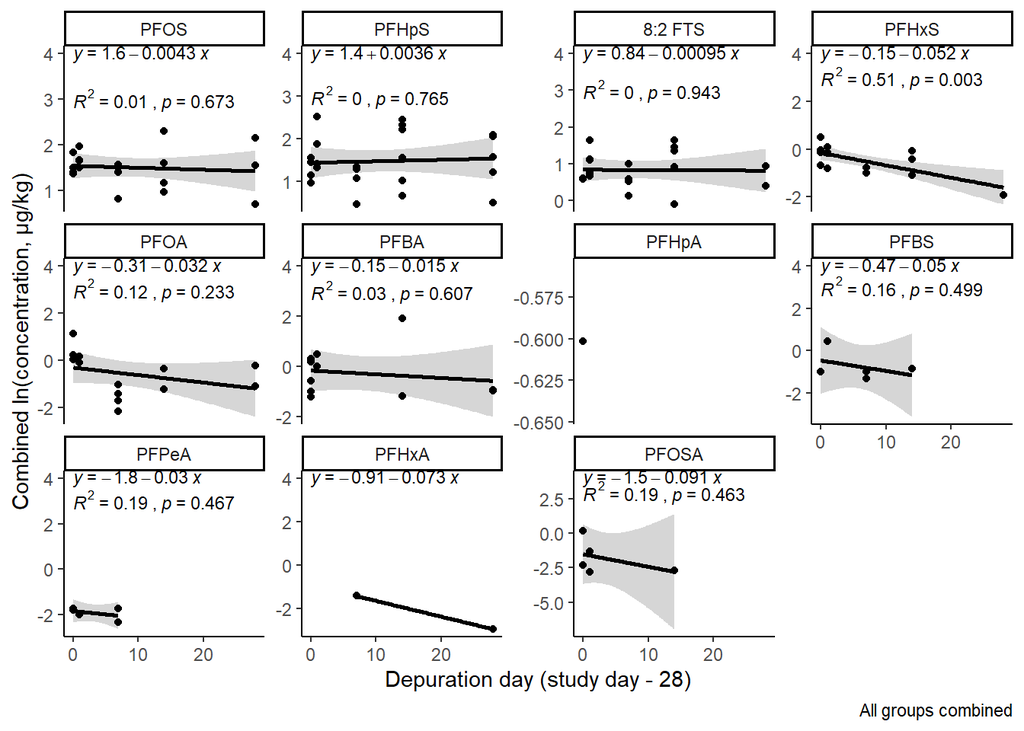

```r
ggplot(data = rabbitwide%>%filter(depday%in%c(0:28)),
       aes(x = depday, y = log(combinedconc3))) +
  stat_smooth(method = "lm", se=T, color="black", formula = y ~ x) +
  geom_point() +
  stat_cor(aes(label = paste(after_stat(rr.label), after_stat(p.label), sep = "~`,`~")),
           r.accuracy = 0.01,
           p.accuracy = 0.001,
           label.x = 0, label.y = 3, size = 3) +
  stat_regline_equation(aes(label = after_stat(eq.label)),
                        label.x = 0, label.y = 4, size = 3) +
  theme_classic() +
  facet_wrap(~fct_reorder(PFAS,log(combinedconc3), .fun=median, .desc=T, .na_rm=T), scales="free_y") +
  labs(y="Combined ln(concentration, \u03BCg/kg)", x="Depuration day (study day - 28)", caption="All groups combined")
```

# Uptake rates using linear regression per OECD TG#305

*Note* that all y-axes here are ln-transformed. So, the slope estimates represent multiplicative increase rates (day 2 is day 1 * slope).

*Note* that the assumption that these uptake data are linear is not pure. Modification of this method to more strictly follow OECD TG#305 would require fitting slope “during linear phase of uptake” which would vary per PFAS, but be approximately between days 0 and 7. In pilot runs, this leads to quite high rates of uptake which leads to stuggles in downstream non-linear models.

Use caution in interpretation of these values as uptake rates.

```r
rabbitwide|> filter(timemod%in%c(0:28)) |> as_tibble() |>
  nest(data = -PFAS) |>
  mutate(
    fit = map(data, ~ lm(log(combinedconc3) ~ timemod, data = .x)),
    tidied = map(fit, tidy)
  ) |>
  unnest(tidied) |>
  #filter(term=="depday") |>
  mutate(
    term=case_when(
      term=="timemod"~"Slope",
      T~"(Intercept)"
    )
  ) |>
  dplyr::select(-c(data,fit,statistic)) |>
  arrange(PFAS) |>
  kable(caption="Parameter estimates for each PFAS with all groups combined. (Intercept) is ln(concentration) for day 0 concentration. Slope is uptake rate across 28 days exposure.")
```

Parameter estimates for each PFAS with all groups combined. (Intercept) is ln(concentration) for day 0 concentration. Slope is uptake rate across 28 days exposure.

| PFAS | term | estimate | std.error | p.value |
| --- | --- | --- | --- | --- |
| 8:2 FTS | (Intercept) | -2.3226133 | 0.1584084 | 0.0000000 |
| 8:2 FTS | Slope | 0.1159380 | 0.0127168 | 0.0000001 |
| PFBA | (Intercept) | -0.0333374 | 0.2653707 | 0.9008950 |
| PFBA | Slope | -0.0067190 | 0.0204955 | 0.7453959 |
| PFBS | (Intercept) | -2.2445707 | 0.3141023 | 0.0000016 |
| PFBS | Slope | 0.0840832 | 0.0399080 | 0.0502808 |
| PFHpA | (Intercept) | -3.3287885 | 0.2353215 | 0.0000000 |
| PFHpA | Slope | 0.1102077 | 0.0284119 | 0.0019004 |
| PFHpS | (Intercept) | -2.4614419 | 0.1944981 | 0.0000000 |
| PFHpS | Slope | 0.1462227 | 0.0147470 | 0.0000000 |
| PFHxA | (Intercept) | -2.9834334 | 0.1288452 | 0.0000000 |
| PFHxA | Slope | 0.1450488 | 0.0486989 | 0.0115182 |
| PFHxS | (Intercept) | -1.7215437 | 0.1192303 | 0.0000000 |
| PFHxS | Slope | 0.0680281 | 0.0083915 | 0.0000000 |
| PFOA | (Intercept) | -1.4088860 | 0.1988372 | 0.0000002 |
| PFOA | Slope | 0.0903375 | 0.0178882 | 0.0000327 |
| PFOS | (Intercept) | -1.0638200 | 0.1432853 | 0.0000010 |
| PFOS | Slope | 0.1038601 | 0.0098519 | 0.0000000 |
| PFOSA | (Intercept) | -3.3350527 | 0.2211880 | 0.0000000 |
| PFOSA | Slope | 0.0839235 | 0.0207789 | 0.0012195 |
| PFPeA | (Intercept) | -3.2964037 | 0.1366931 | 0.0000000 |
| PFPeA | Slope | 0.0603466 | 0.0133145 | 0.0002579 |

```r
uptakerates <- rabbitwide|> filter(timemod%in%c(0:28)) |> as_tibble() |>
  nest(data = -PFAS) |>
  mutate(
    fit = map(data, ~ lm(log(combinedconc3) ~ timemod, data = .x)),
    tidied = map(fit, tidy)
  ) |>
  unnest(tidied) |>
  filter(term=="timemod") |>
  dplyr::select(-c(data,fit,statistic))


rabbitwide|> filter(timemod%in%c(0:28)) |> as_tibble() |>
  nest(data = -c(group,PFAS)) |>
  mutate(
    fit = map(data, ~ lm(log(combinedconc3) ~ timemod, data = .x)),
    tidied = map(fit, tidy)
  ) |>
  unnest(tidied) |>
  #filter(term=="depday") |>
  mutate(
    term=case_when(
      term=="timemod"~"Slope",
      T~"(Intercept)"
    )
  ) |>
  dplyr::select(-c(data,fit,statistic)) |>
  arrange(group,PFAS) |>
  kable(caption="Parameter estimates for each PFAS by group. (Intercept) is ln(concentration) for day 0 concentration. Slope is uptake rate across 28 days exposure.")
```

Parameter estimates for each PFAS by group. (Intercept) is ln(concentration) for day 0 concentration. Slope is uptake rate across 28 days exposure.

| PFAS | group | term | estimate | std.error | p.value |
| --- | --- | --- | --- | --- | --- |
| 8:2 FTS | 1 | (Intercept) | -2.4651161 | 0.0385617 | 0.0000084 |
| 8:2 FTS | 1 | Slope | NA | NA | NA |
| PFBA | 1 | (Intercept) | 0.4280705 | 0.1403345 | 0.0137849 |
| PFBA | 1 | Slope | -0.0429355 | 0.0102573 | 0.0023556 |
| PFBS | 1 | (Intercept) | -1.7228279 | 0.6690590 | 0.0821354 |
| PFBS | 1 | Slope | NA | NA | NA |
| PFHpA | 1 | (Intercept) | -3.5160885 | 0.1200454 | 0.0000874 |
| PFHpA | 1 | Slope | NA | NA | NA |
| PFHpS | 1 | (Intercept) | -2.8140620 | 0.0243632 | 0.0000014 |
| PFHpS | 1 | Slope | NA | NA | NA |
| PFHxA | 1 | (Intercept) | -2.8750161 | 0.3143399 | 0.0027629 |
| PFHxA | 1 | Slope | 0.1886946 | 0.1004122 | 0.1568191 |
| PFHxS | 1 | (Intercept) | -1.8165811 | 0.2723664 | 0.0026261 |
| PFHxS | 1 | Slope | 0.0944996 | 0.0213116 | 0.0113850 |
| PFOA | 1 | (Intercept) | -1.2721816 | 0.3324490 | 0.0033368 |
| PFOA | 1 | Slope | 0.0900548 | 0.0253736 | 0.0052757 |
| PFOSA | 1 | (Intercept) | -3.4322731 | 0.0534226 | 0.0000083 |
| PFOSA | 1 | Slope | NA | NA | NA |
| PFPeA | 1 | (Intercept) | -2.8644300 | 0.2184364 | 0.0000004 |
| PFPeA | 1 | Slope | 0.0413751 | 0.0159659 | 0.0291433 |
| 8:2 FTS | 2 | (Intercept) | -2.1174844 | 0.4493277 | 0.0092222 |
| 8:2 FTS | 2 | Slope | 0.1124981 | 0.0381343 | 0.0419674 |
| PFBA | 2 | (Intercept) | 0.9331260 | 0.3456327 | 0.0244032 |
| PFBA | 2 | Slope | -0.0255738 | 0.0252629 | 0.3378310 |
| PFBS | 2 | (Intercept) | -2.6250703 | 0.2719571 | 0.0006444 |
| PFBS | 2 | Slope | 0.1374483 | 0.0672919 | 0.1106203 |
| PFHpA | 2 | (Intercept) | -2.8115326 | 0.6533509 | 0.0126131 |
| PFHpA | 2 | Slope | 0.0879865 | 0.0511221 | 0.1603430 |
| PFHpS | 2 | (Intercept) | -2.2895562 | 0.4361131 | 0.0033265 |
| PFHpS | 2 | Slope | 0.1434389 | 0.0286941 | 0.0041086 |
| PFHxA | 2 | (Intercept) | -2.8737332 | 0.2192148 | 0.0009588 |
| PFHxA | 2 | Slope | 0.0702434 | 0.0700256 | 0.3897183 |
| PFHxS | 2 | (Intercept) | -1.8679365 | 0.1475960 | 0.0000044 |
| PFHxS | 2 | Slope | 0.0702263 | 0.0098788 | 0.0001922 |
| PFOA | 2 | (Intercept) | -0.9123178 | 0.2276088 | 0.0030719 |
| PFOA | 2 | Slope | 0.0520608 | 0.0211329 | 0.0359521 |
| PFOS | 2 | (Intercept) | -0.9431507 | 0.2262215 | 0.0041936 |
| PFOS | 2 | Slope | 0.1043507 | 0.0151414 | 0.0002330 |
| PFOSA | 2 | (Intercept) | -3.1445735 | 0.4224098 | 0.0017391 |
| PFOSA | 2 | Slope | 0.1340169 | 0.0358498 | 0.0201511 |
| PFPeA | 2 | (Intercept) | -3.5436135 | 0.0910395 | 0.0000373 |
| PFPeA | 2 | Slope | NA | NA | NA |
| 8:2 FTS | 3 | (Intercept) | -2.4034035 | 0.2116964 | 0.0000280 |
| 8:2 FTS | 3 | Slope | 0.1171993 | 0.0135248 | 0.0001303 |
| PFBA | 3 | (Intercept) | -1.4989035 | 0.4150301 | 0.0086064 |
| PFBA | 3 | Slope | 0.0447821 | 0.0379044 | 0.2760025 |
| PFBS | 3 | (Intercept) | -2.3374462 | 0.6256333 | 0.0072998 |
| PFBS | 3 | Slope | 0.0890796 | 0.0571387 | 0.1629575 |
| PFHpA | 3 | (Intercept) | -3.6859081 | 0.0023584 | 0.0000000 |
| PFHpA | 3 | Slope | 0.1622868 | 0.0007534 | 0.0000002 |
| PFHpS | 3 | (Intercept) | -2.3332196 | 0.3431905 | 0.0002535 |
| PFHpS | 3 | Slope | 0.1370401 | 0.0238598 | 0.0007031 |
| PFHxA | 3 | (Intercept) | -3.2015508 | 0.0017197 | 0.0000000 |
| PFHxA | 3 | Slope | NA | NA | NA |
| PFHxS | 3 | (Intercept) | -1.4970858 | 0.1997285 | 0.0000696 |
| PFHxS | 3 | Slope | 0.0510009 | 0.0139225 | 0.0063717 |
| PFOA | 3 | (Intercept) | -2.4885150 | 0.0739812 | 0.0000578 |
| PFOA | 3 | Slope | NA | NA | NA |
| PFOS | 3 | (Intercept) | -1.1645181 | 0.1917824 | 0.0002985 |
| PFOS | 3 | Slope | 0.1025156 | 0.0135273 | 0.0000643 |
| PFOSA | 3 | (Intercept) | -3.4381977 | 0.0151927 | 0.0000000 |
| PFOSA | 3 | Slope | 0.0389619 | 0.0011888 | 0.0000052 |
| PFPeA | 3 | (Intercept) | -3.6353243 | 0.0016038 | 0.0000000 |
| PFPeA | 3 | Slope | 0.0331910 | 0.0005123 | 0.0000081 |

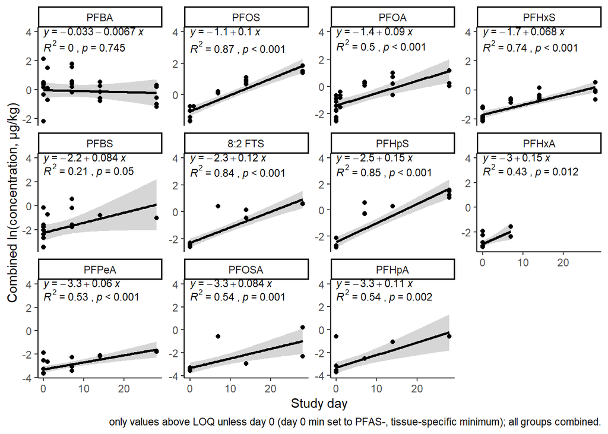

```r
ggplot(data = rabbitwide%>%filter(timemod%in%c(0:28)),
       aes(x = timemod, y = log(combinedconc3))) +
  stat_smooth(method = "lm", se=T, color="black", formula = y ~ x) +
  geom_point() +
  stat_cor(aes(label = paste(after_stat(rr.label), after_stat(p.label), sep = "~`,`~")),
           r.accuracy = 0.01,
           p.accuracy = 0.001,
           label.x = 0, label.y = 3, size = 3) +
  stat_regline_equation(aes(label = after_stat(eq.label)),
                        label.x = 0, label.y = 4, size = 3) +
  theme_classic() +
  facet_wrap(~fct_reorder(PFAS,log(combinedconc3), .fun=median, .desc=T, .na_rm=T), scales="free_y") +
  labs(y="Combined ln(concentration, \u03BCg/kg)", x="Study day", caption="only values above LOQ unless day 0 (day 0 min set to PFAS-, tissue-specific minimum); all groups combined.")
```

# PFAS-specific non-linear models

Group 1 excluded from PFOS and “RF61” excluded from all.

## PFOS

mean diet is 7.1  
mean starting background is 0.2927293  
elimination rate is 0.0043 (negative is in function not value) with se of 0.0099  
starting uptake is 0.1

*NOTE* PFOS has group 1 excluded.

```r
oswb <- rabbitwide |> filter(PFAS=="PFOS")
oswb$meanuptakediet <- mean(oswb$meandietconc[oswb$timemod<=28])
oswb$background <- mean(rabbitwide$combinedconc3[rabbitwide$PFAS=="PFOS"&rabbitwide$timemod==0])
oswb$elimrate <- -elimrates$estimate[elimrates$PFAS=="PFOS"] #note that this requires changing the sign to "positive"
oswb$uprate <- uptakerates$estimate[uptakerates$PFAS=="PFOS"]


oswbnls <- nls(combinedconc3~background+((meanuptakediet*k01)/(V*(k01-elimrate)))*(exp(-elimrate*timemod)-exp(-k01*timemod)),
               #combinedconc3~0.2927293+((7.1*k01)/(V*(k01-0.029)))*(exp(-0.029*timemod)-exp(-k01*timemod)),
               data=oswb,
               start=list(V=1, k01=0.1) ,upper=c(10,1), lower=c(0,0),algorithm="port"#,trace=T
             )
```

### Parametric estimate of uptake rate and Vd using OECD elimination rate

```r
summary(oswbnls)
```

```
##
## Formula: combinedconc3 ~ background + ((meanuptakediet * k01)/(V * (k01 -
##     elimrate))) * (exp(-elimrate * timemod) - exp(-k01 * timemod))
##
## Parameters:
##     Estimate Std. Error t value Pr(>|t|)
## V    1.04579    0.28608   3.656 0.000912 ***
## k01  0.03690    0.02068   1.785 0.083792 .
## ---
## Signif. codes:  0 '***' 0.001 '**' 0.01 '*' 0.05 '.' 0.1 ' ' 1
##
## Residual standard error: 1.576 on 32 degrees of freedom
##
## Algorithm "port", convergence message: relative convergence (4)
##   (5 observations deleted due to missingness)
```

```r
#overview(oswbnls)
```

```r
oswbnlsboot <- nlsBoot(nls(combinedconc3~background+((meanuptakediet*k01)/(V*(k01-elimrate)))*(exp(-elimrate*timemod)-exp(-k01*timemod)),
               data=oswb|>filter(!is.na(combinedconc3)),
               start=list(V=1, k01=0.1) ,upper=c(10,1), lower=c(0,0),algorithm="port"#,trace=T
             ))
```

### Bootstrap estimate of uptake rate and Vd using OECD elimination rate

```r
summary(oswbnlsboot)
```

```
##
## ------
## Bootstrap statistics
##       Estimate Std. error
## V   1.01612224 0.28069122
## k01 0.04186333 0.02671724
##
## ------
## Median of bootstrap estimates and percentile confidence intervals
##        Median        2.5%     97.5%
## V   1.0678797 0.341307512 1.4548546
## k01 0.0384362 0.007409276 0.0989612
```

```r
oswb$uptakeboot <- oswbnlsboot$estiboot[2,1]
oswbnlsboot2 <- nlsBoot(nls(combinedconc3~background+((meanuptakediet*uptakeboot)/(V*(uptakeboot-k10)))*(exp(-k10*timemod)-exp(-uptakeboot*timemod)),
               data=oswb|>filter(!is.na(combinedconc3)),
               start=list(V=1, k10=0.0043) ,upper=c(10,1), lower=c(0,0),algorithm="port"#,trace=T
             ))
```

### Bootstrap estimate of elimination rate and Vd using bootstrap uptake rate

```r
summary(oswbnlsboot2)
```

```
##
## ------
## Bootstrap statistics
##        Estimate Std. error
## V   1.101959337 0.16404809
## k10 0.005263339 0.00626353
##
## ------
## Median of bootstrap estimates and percentile confidence intervals
##          Median      2.5%      97.5%
## V   1.121721824 0.7563446 1.38608864
## k10 0.003075121 0.0000000 0.02107943
```

```r
oswb$elimboot <- oswbnlsboot2$estiboot[2,1]
```

```r
bafvectoswb <- data.frame(
  up=c(sample(oswbnlsboot$coefboot[,2], size=10000, replace=T)),
  down=c(sample(oswbnlsboot2$coefboot[,2], size=10000, replace=T)),
  PFAS="PFOS"
  )

#nlsBootPredict(oswbnlsboot,
#               newdata=data.frame(
#                 timemod=seq(0,56,1),
#                 background=oswb$background[1],
#                 meanuptakediet=oswb$meanuptakediet[1],
#                 elimrate=oswb$elimrate[1]
#                 #uptakeboot=oswbnlsboot$estiboot[2,1]
#               ), interval="confidence")


oswbnlspredboot <- data.frame(
  nlsBootPredict(
    oswbnlsboot, newdata=data.frame(
      timemod=seq(0,56,by=0.1),
      background=oswb$background[1],
      meanuptakediet=oswb$meanuptakediet[1],
      elimrate=oswb$elimrate[1]
      #uptakeboot=oswbnlsboot$estiboot[2,1]
      ), interval="confidence"))
oswbnlspredboot$timemod <- c(seq(from=0,to=56,by=0.1))

oswbnlspredboot2 <- data.frame(
  nlsBootPredict(
    oswbnlsboot2, newdata=data.frame(
      timemod=seq(0,56,by=0.1),
      background=oswb$background[1],
      meanuptakediet=oswb$meanuptakediet[1],
      #elimrate=oswb$elimrate[1]
      uptakeboot=oswbnlsboot$estiboot[2,1]
      ), interval="confidence"))
oswbnlspredboot2$timemod <- c(seq(from=0,to=56,by=0.1))
```

### Summary of whole rabbit PFOS concentations on day 28 via bootstraps

```r
data.frame(
  day=oswbnlspredboot[oswbnlspredboot$timemod==28,4],
  medianestimate=oswbnlspredboot[oswbnlspredboot$timemod==28,1],
  lowerestimate=oswbnlspredboot[oswbnlspredboot$timemod==28,2],
  upperestimate=oswbnlspredboot[oswbnlspredboot$timemod==28,3]
  )|> kable(caption="Day 28 PFOS bootstrap whole animal estimate using nonlinear uptake rate and Vd and OECD elimination rate")
```

Day 28 PFOS bootstrap whole animal estimate using nonlinear uptake rate and Vd and OECD elimination rate

| day | medianestimate | lowerestimate | upperestimate |
| --- | --- | --- | --- |
| 28 | 4.352338 | 3.702827 | 5.058877 |

```r
data.frame(
  day=oswbnlspredboot2[oswbnlspredboot2$timemod==28,4],
  medianestimate=oswbnlspredboot2[oswbnlspredboot2$timemod==28,1],
  lowerestimate=oswbnlspredboot2[oswbnlspredboot2$timemod==28,2],
  upperestimate=oswbnlspredboot2[oswbnlspredboot2$timemod==28,3]
  )|> kable(caption="Day 28 PFOS bootstrap whole animal estimate using bootstrap estimate of nonlinear elimination rate and Vd using bootstrap uptake rate")
```

Day 28 PFOS bootstrap whole animal estimate using bootstrap estimate of nonlinear elimination rate and Vd using bootstrap uptake rate

| day | medianestimate | lowerestimate | upperestimate |
| --- | --- | --- | --- |
| 28 | 4.431344 | 3.793802 | 5.212616 |

### Summary of uptake rates via bootstrap estimates

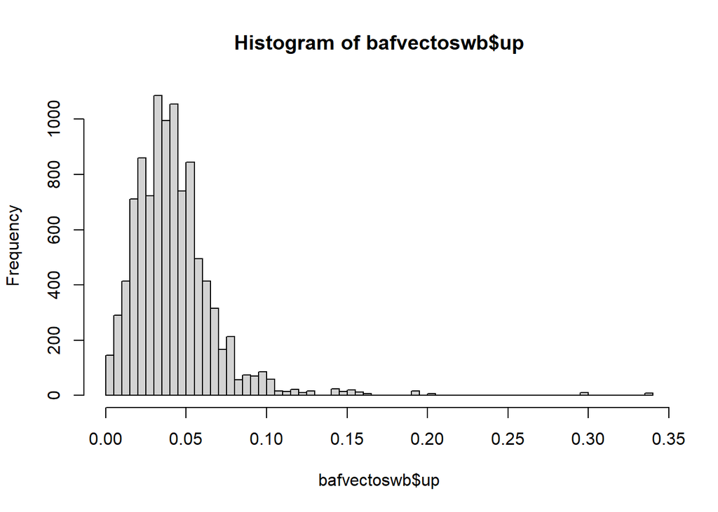

```r
#summary(bafvectoswb$up) # up
#sd(bafvectoswb$up)
#quantile(bafvectoswb$up, probs=c(0.025,0.975))
hist(bafvectoswb$up, breaks=100)
```

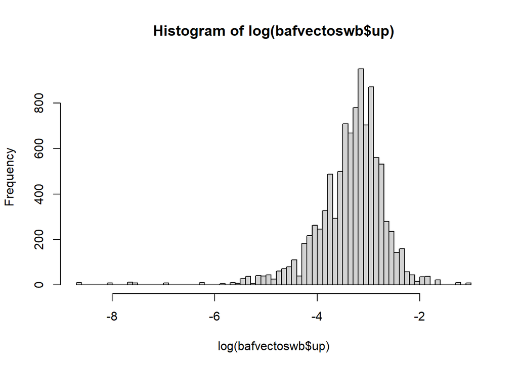

```r
hist(log(bafvectoswb$up), breaks=100)
```

```r
data.frame(
  mean=mean(bafvectoswb$up),
  median=median(bafvectoswb$up),
  sd=sd(bafvectoswb$up),
  twentyfifth=quantile(bafvectoswb$up, probs=c(0.25), names=F),
  seventyfifth=quantile(bafvectoswb$up, probs=c(0.75), names=F),
  lower=quantile(bafvectoswb$up, probs=c(0.025), names=F),
  upper=quantile(bafvectoswb$up, probs=0.975, names=F),
  min=min(bafvectoswb$up),
  max=max(bafvectoswb$up)
) |>
  kable(caption="summary stats of uptake rate bootstrap distribution")
```

summary stats of uptake rate bootstrap distribution

| mean | median | sd | twentyfifth | seventyfifth | lower | upper | min | max |
| --- | --- | --- | --- | --- | --- | --- | --- | --- |
| 0.042251 | 0.0388748 | 0.0265465 | 0.0253084 | 0.0523362 | 0.0071804 | 0.0993477 | 0.0001716 | 0.3352778 |

### Summary of elimination rates via bootstrap estimates

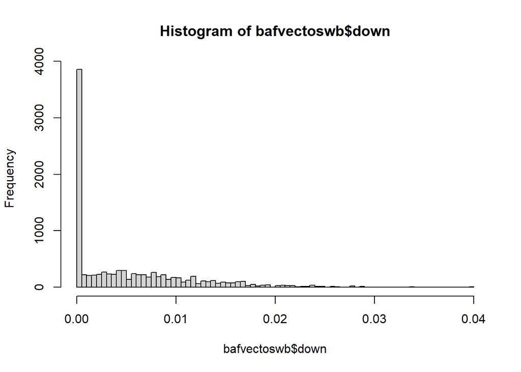

```r
#summary(bafvectoswb$down) # elim
#sd(bafvectoswb$down)
#quantile(bafvectoswb$down, probs=c(0.025,0.975))
hist(bafvectoswb$down, breaks=100)
```

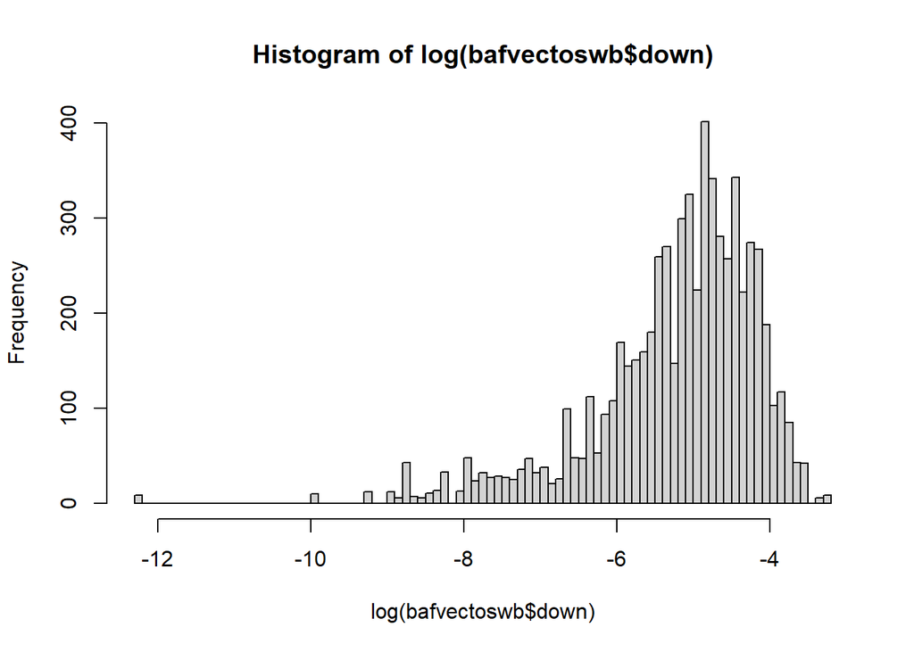

```r
hist(log(bafvectoswb$down), breaks=100)
```

```r
data.frame(
  mean=mean(bafvectoswb$down),
  median=median(bafvectoswb$down),
  sd=sd(bafvectoswb$down),
  twentyfifth=quantile(bafvectoswb$down, probs=c(0.25), names=F),
  seventyfifth=quantile(bafvectoswb$down, probs=c(0.75), names=F),
  lower=quantile(bafvectoswb$down, probs=c(0.025), names=F),
  upper=quantile(bafvectoswb$down, probs=0.975, names=F),
  min=min(bafvectoswb$down),
  max=max(bafvectoswb$down)
) |>
  kable(caption="summary stats of elimination rate bootstrap distribution")
```

summary stats of elimination rate bootstrap distribution

| mean | median | sd | twentyfifth | seventyfifth | lower | upper | min | max |
| --- | --- | --- | --- | --- | --- | --- | --- | --- |
| 0.0051633 | 0.0030226 | 0.0061843 | 0 | 0.0085487 | 0 | 0.0210713 | 0 | 0.0397701 |

### half-life using bootstrapped elimination rates

Median half-life of PFOS is 229.3182582 with lower at 32.8953467 and upper at Inf.

```r
summary(log(2)/bafvectoswb$down)
```

```
##    Min. 1st Qu.  Median    Mean 3rd Qu.    Max.
##   17.43   81.08  229.32     Inf     Inf     Inf
```

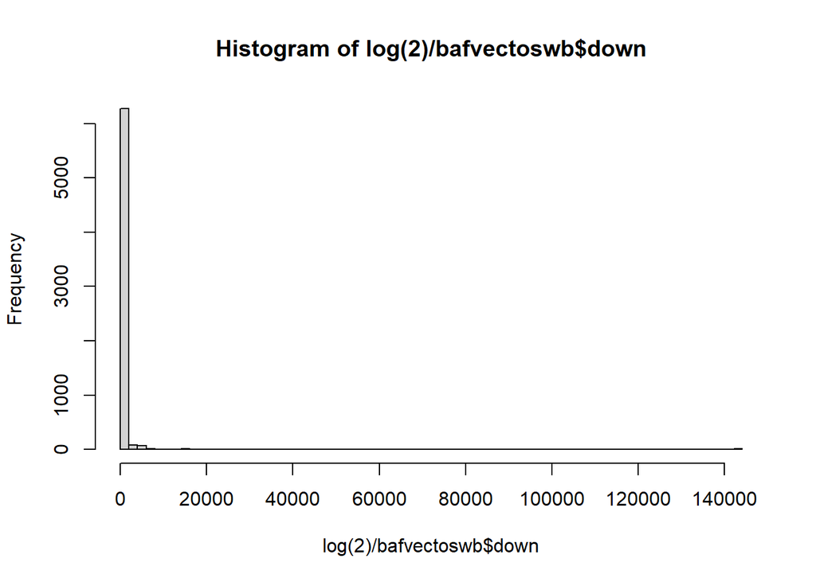

```r
hist(log(2)/bafvectoswb$down, breaks=100)
```

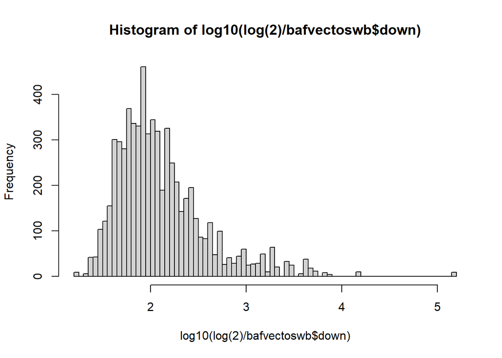

```r
hist(log10(log(2)/bafvectoswb$down), breaks=100)
```

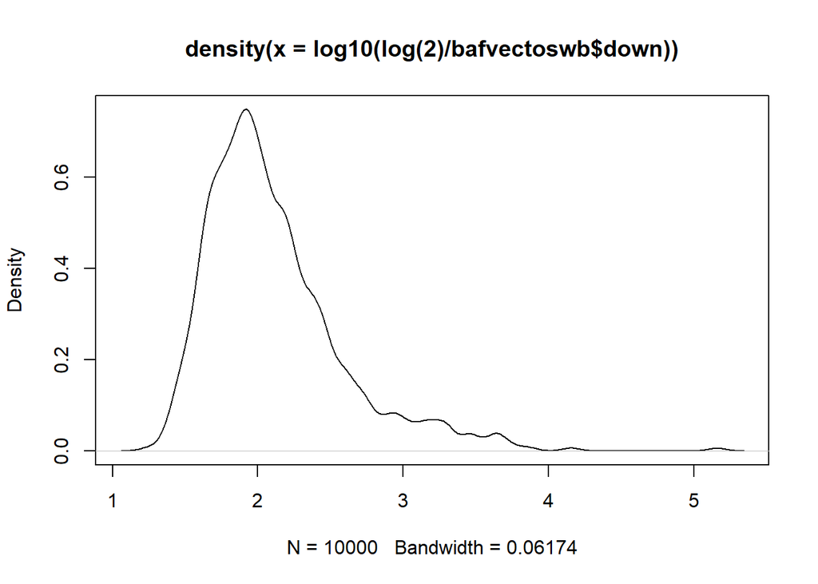

```r
plot(density(log10(log(2)/bafvectoswb$down)))
```

### Summary of TTC (uptake/elimination) and ln(TTC) resampling

```r
bafvectoswb <- data.frame(up=c(bafvectoswb$up), down=c(bafvectoswb$down))
bafvectoswb$baf <- bafvectoswb$up/bafvectoswb$down

data.frame(
  mean=mean(bafvectoswb$baf),
  median=median(bafvectoswb$baf),
  sd=sd(bafvectoswb$baf),
  twentyfifth=quantile(bafvectoswb$baf, probs=c(0.25), names=F),
  seventyfifth=quantile(bafvectoswb$baf, probs=c(0.75), names=F),
  lower=quantile(bafvectoswb$baf, probs=c(0.025), names=F),
  upper=quantile(bafvectoswb$baf, probs=0.975, names=F),
  min=min(bafvectoswb$baf),
  max=max(bafvectoswb$baf)
) |>
  kable(caption="summary stats of TTC bootstrap distribution")
```

summary stats of TTC bootstrap distribution

| mean | median | sd | twentyfifth | seventyfifth | lower | upper | min | max |
| --- | --- | --- | --- | --- | --- | --- | --- | --- |
| Inf | 13.62236 | NaN | 4.264091 | Inf | 0.9978848 | Inf | 0.0110332 | Inf |

```r
data.frame(
  mean=mean(log(bafvectoswb$baf)),
  median=median(log(bafvectoswb$baf)),
  sd=sd(log(bafvectoswb$baf)),
  twentyfifth=quantile(log(bafvectoswb$baf), probs=c(0.25), names=F),
  seventyfifth=quantile(log(bafvectoswb$baf), probs=c(0.75), names=F),
  lower=quantile(log(bafvectoswb$baf), probs=c(0.025), names=F),
  upper=quantile(log(bafvectoswb$baf), probs=0.975, names=F),
  min=min(log(bafvectoswb$baf)),
  max=max(log(bafvectoswb$baf))
) |>
  kable(caption="summary stats of log(TTC) bootstrap distribution")
```

summary stats of log(TTC) bootstrap distribution

| mean | median | sd | twentyfifth | seventyfifth | lower | upper | min | max |
| --- | --- | --- | --- | --- | --- | --- | --- | --- |
| Inf | 2.611713 | NaN | 1.450229 | Inf | -0.0021175 | Inf | -4.506849 | Inf |

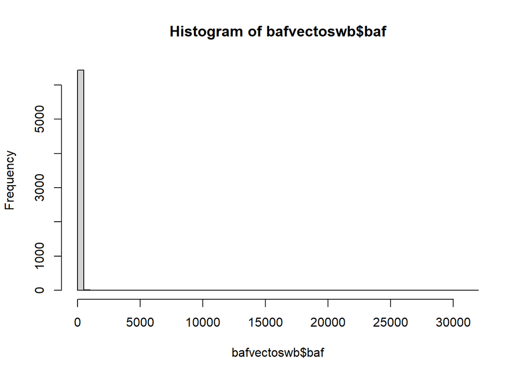

```r
hist(bafvectoswb$baf, breaks=100)
```

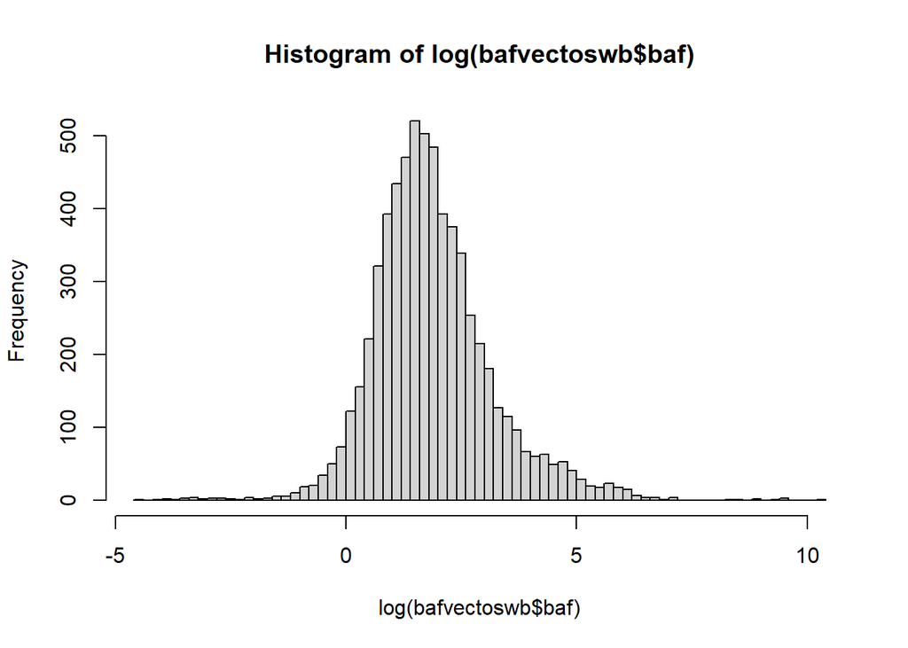

```r
hist(log(bafvectoswb$baf), breaks=100)
```

## PFOS estimate at 56 days constant exposure

Requires fitting nonlinear model through just 28 days–is not the suggested route of the original authors. This is due to the desire to concurrently estimate uptake, elimination, and Vd parameters. So, if that’s not needed, does not need to be performed.

Target estimated concentration at day 56 of constant exposure (assume no elimination period in study).

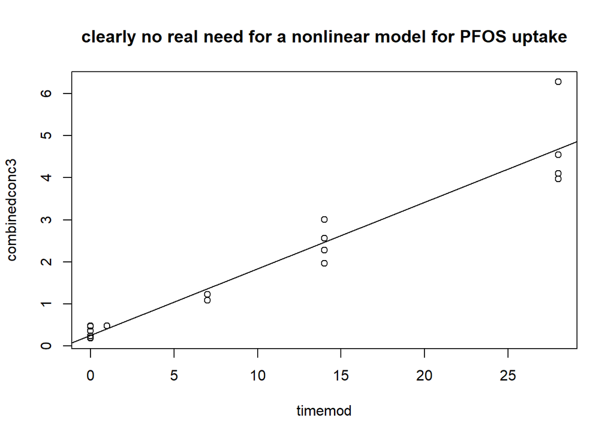

```r
plot(combinedconc3~timemod, data=oswb|>filter(!is.na(combinedconc3))|>filter(timemod<=28), main="clearly no real need for a nonlinear model for PFOS uptake")
abline(lm(combinedconc3~timemod, data=oswb|>filter(!is.na(combinedconc3))|>filter(timemod<=28)))
```

```r
summary(lm(combinedconc3~timemod, data=oswb|>filter(!is.na(combinedconc3))|>filter(timemod<=28)))
```

```
##
## Call:
## lm(formula = combinedconc3 ~ timemod, data = filter(filter(oswb,
##     !is.na(combinedconc3)), timemod <= 28))
##
## Residuals:
##      Min       1Q   Median       3Q      Max
## -0.71387 -0.17162 -0.06554  0.09929  1.59040
##
## Coefficients:
##             Estimate Std. Error t value Pr(>|t|)
## (Intercept)  0.25586    0.15250   1.678    0.112
## timemod      0.15829    0.01049  15.097  2.8e-11 ***
## ---
## Signif. codes:  0 '***' 0.001 '**' 0.01 '*' 0.05 '.' 0.1 ' ' 1
##
## Residual standard error: 0.4981 on 17 degrees of freedom
## Multiple R-squared:  0.9306, Adjusted R-squared:  0.9265
## F-statistic: 227.9 on 1 and 17 DF,  p-value: 2.796e-11
```

```r
oswblm <- lm(combinedconc3~timemod, data=oswb|>filter(!is.na(combinedconc3))|>filter(timemod<=28))
predict(oswblm, newdata=data.frame(timemod=56), interval="confidence") |> kable(caption="linear model predicted whole animal PFOS concentration and 95% confidence intervals.")
```

linear model predicted whole animal PFOS concentration and 95% confidence intervals.

| fit | lwr | upr |
| --- | --- | --- |
| 9.120265 | 8.066551 | 10.17398 |

```r
# uptake rate is most likely 0.15829

oswbnlsbootday56 <- nlsBoot(nls(combinedconc3~background+((meanuptakediet*k01)/(V*(k01-k10)))*(exp(-k10*timemod)-exp(-k01*timemod)),
                        data=oswb|>filter(!is.na(combinedconc3))|>filter(timemod<=29),
                        start=list(V=5, k10=0, k01=0.16), upper=c(100,2,2), lower=c(0,-2,-2),algorithm="port"))
#oswbnlsbootday56b <- nlsBoot(nlsLM(combinedconc3~background+((meanuptakediet*k01)/(V*(k01-0.002)))*(exp(-0.002*timemod)-exp(-k01*timemod)),
#                        data=oswb|>filter(!is.na(combinedconc3))|>filter(timemod<=28),
#                        start=list(V=1, k01=0.003397), upper=c(10,2), lower=c(0,-2),algorithm="port"))

#testfit <- nls_multstart(
#  combinedconc3~background+((meanuptakediet*k01)/(V*(k01-0.002)))*(exp(-0.002*timemod)-exp(-k01*timemod)),
#  data=oswb|>filter(!is.na(combinedconc3))|>filter(timemod<=28),
#  iter=c(10,1000),
#  lower=c(V=0,k01=0),
#  upper=c(V=10, k01=1),
#  start_lower=c(V=0.5,k01=0),
#  start_upper=c(V=1,k01=1),
#  supp_errors="Y",
#  convergence_count=F
#)
#summary(testfit)
#
#
#testfit2 <- nls_multstart(
#  combinedconc3~background+((meanuptakediet*k01)/(V*(k01-K10)))*(exp(-K10*timemod)-exp(-k01*timemod)),
#  data=oswb|>filter(!is.na(combinedconc3))|>filter(timemod<=28),
#  iter=c(10,100,100),
#  lower=c(V=0,k01=0,k10=0),
#  upper=c(V=10, k01=1,k10=1),
#  start_lower=c(V=0.5,k01=0,k10=0),
#  start_upper=c(V=1,k01=0.1,k10=1),
#  supp_errors="Y",
#  convergence_count=F
#)
#summary(testfit2)
#0.0042658
```

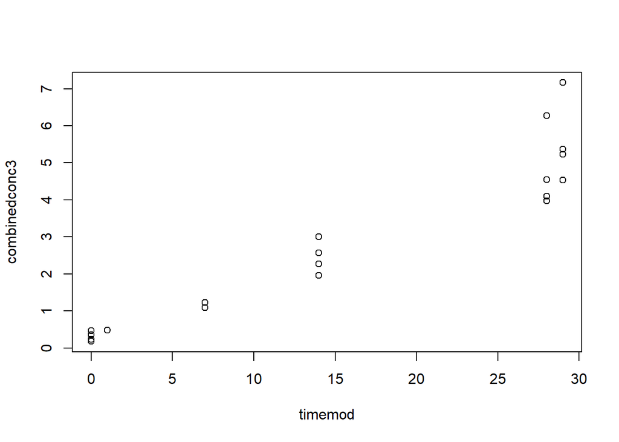

```r
plot(combinedconc3~timemod, data=oswb|>filter(timemod<=29))
```

```r
summary(oswbnlsbootday56)
```

```
##
## ------
## Bootstrap statistics
##        Estimate Std. error
## V    6.47473349 2.74748387
## k10 -0.05830467 0.01233579
## k01  0.55317824 0.66630922
##
## ------
## Median of bootstrap estimates and percentile confidence intervals
##          Median        2.5%       97.5%
## V    6.56882521  1.30870077 11.56135427
## k10 -0.05971749 -0.07928564 -0.02906859
## k01  0.27382486  0.02553572  2.00000000
```

```r
#summary(oswbnlsbootday56b)
```

```r
oswbnlspredbootday56 <- data.frame(
  nlsBootPredict(
    oswbnlsbootday56, newdata=data.frame(
      timemod=seq(0,56,by=1),
      background=oswb$background[1],
      meanuptakediet=oswb$meanuptakediet[1]#,
      #elimrate=oswb$elimrate[1]
      #uptakeboot=oswbnlsboot$estiboot[2,1]
      ), interval="confidence"))
oswbnlspredbootday56$timemod <- c(seq(from=0,to=56,by=1))




#oswbnlspredbootday56b <- data.frame(
#  nlsBootPredict(
#    oswbnlsbootday56b, newdata=data.frame(
#      timemod=seq(0,56,by=1),
#      background=oswb$background[1],
#      meanuptakediet=oswb$meanuptakediet[1]#,
#      #elimrate=oswb$elimrate[1]
#      #uptakeboot=oswbnlsboot$estiboot[2,1]
#      ), interval="confidence"))
#oswbnlspredbootday56b$timemod <- c(seq(from=0,to=56,by=1))
```

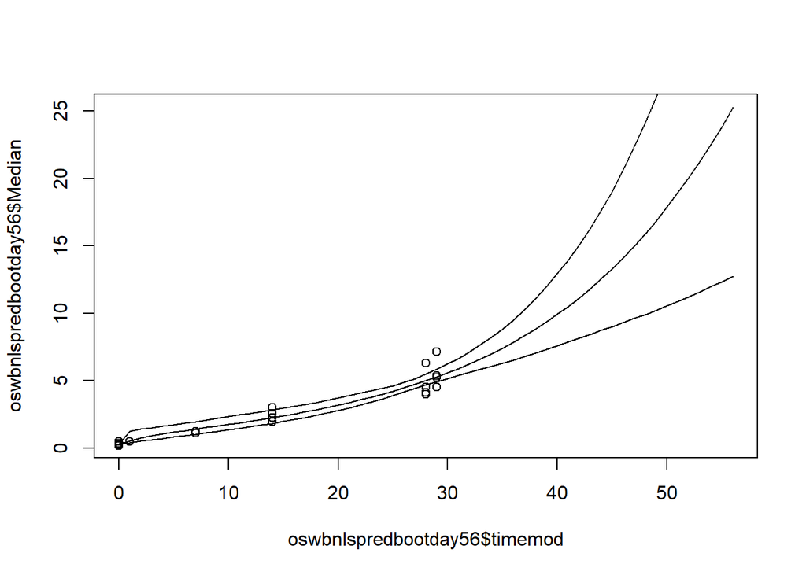

```r
plot(oswbnlspredbootday56$Median~oswbnlspredbootday56$timemod, type="l")
points(combinedconc3~timemod, data=oswb|>filter(!is.na(combinedconc3))|>filter(timemod<=29))
points(oswbnlspredbootday56$X2.5.~oswbnlspredbootday56$timemod, type="l")
points(oswbnlspredbootday56$X97.5.~oswbnlspredbootday56$timemod, type="l")
```

```r
#plot(oswbnlspredbootday56b$Median~oswbnlspredbootday56b$timemod, type="l")
#points(combinedconc3~timemod, data=oswb|>filter(!is.na(combinedconc3))|>filter(timemod<=29))
#points(oswbnlspredbootday56b$X2.5.~oswbnlspredbootday56b$timemod, type="l")
#points(oswbnlspredbootday56b$X97.5.~oswbnlspredbootday56b$timemod, type="l")
```

```r
data.frame(
  day=oswbnlspredbootday56[oswbnlspredbootday56$timemod==56,4],
  medianestimate=oswbnlspredbootday56[oswbnlspredbootday56$timemod==56,1],
  lowerestimate=oswbnlspredbootday56[oswbnlspredbootday56$timemod==56,2],
  upperestimate=oswbnlspredbootday56[oswbnlspredbootday56$timemod==56,3]
  )|> kable(caption="Day 56 PFOS bootstrap whole animal estimate using nonlinear model fit to data only during uptake period")
```

Day 56 PFOS bootstrap whole animal estimate using nonlinear model fit to data only during uptake period

| day | medianestimate | lowerestimate | upperestimate |
| --- | --- | --- | --- |
| 56 | 25.25281 | 12.75049 | 44.96236 |

```r
#data.frame(
#  day=oswbnlspredbootday56b[oswbnlspredbootday56b$timemod==56,4],
#  medianestimate=oswbnlspredbootday56b[oswbnlspredbootday56b$timemod==56,1],
#  lowerestimate=oswbnlspredbootday56b[oswbnlspredbootday56b$timemod==56,2],
#  upperestimate=oswbnlspredbootday56b[oswbnlspredbootday56b$timemod==56,3]
#  )|> kable(caption="Day 56 PFOS bootstrap whole animal estimate using nonlinear model fit to data only during uptake period")
```

## 8:2 FTS

mean diet is 20.315 mean starting background is 0.0835470  
elimination rate is 0.0009490 (negative is in function not value) with se of 0.0131191  
starting uptake is 0.1159380

```r
ftswb <- rabbitwide |> filter(PFAS=="8:2 FTS")
ftswb$meanuptakediet <- mean(ftswb$meandietconc[ftswb$timemod<=28])
ftswb$background <- mean(rabbitwide$combinedconc3[rabbitwide$PFAS=="8:2 FTS"&rabbitwide$timemod==0])
ftswb$elimrate <- -elimrates$estimate[elimrates$PFAS=="8:2 FTS"] #note that this requires changing the sign to "positive"
ftswb$uprate <- uptakerates$estimate[uptakerates$PFAS=="8:2 FTS"]


ftswbnls <- nls(combinedconc3~background+((meanuptakediet*k01)/(V*(k01-elimrate)))*(exp(-elimrate*timemod)-exp(-k01*timemod)),
               #combinedconc3~0.2927293+((7.1*k01)/(V*(k01-0.029)))*(exp(-0.029*timemod)-exp(-k01*timemod)),
               data=ftswb,
               start=list(V=1, k01=0.1) ,upper=c(10,1), lower=c(0,0),algorithm="port"#,trace=T
             )
```

### Parametric estimate of uptake rate and Vd using OECD elimination rate

```r
summary(ftswbnls)
```

```
##
## Formula: combinedconc3 ~ background + ((meanuptakediet * k01)/(V * (k01 -
##     elimrate))) * (exp(-elimrate * timemod) - exp(-k01 * timemod))
##
## Parameters:
##     Estimate Std. Error t value Pr(>|t|)
## V    6.75969    1.89680   3.564  0.00117 **
## k01  0.05061    0.03762   1.345  0.18805
## ---
## Signif. codes:  0 '***' 0.001 '**' 0.01 '*' 0.05 '.' 0.1 ' ' 1
##
## Residual standard error: 0.966 on 32 degrees of freedom
##
## Algorithm "port", convergence message: relative convergence (4)
##   (24 observations deleted due to missingness)
```

```r
#overview(ftswbnls)
```

```r
ftswbnlsboot <- nlsBoot(nls(combinedconc3~background+((meanuptakediet*k01)/(V*(k01-elimrate)))*(exp(-elimrate*timemod)-exp(-k01*timemod)),
               data=ftswb|>filter(!is.na(combinedconc3)),
               start=list(V=1, k01=0.1) ,upper=c(10,1), lower=c(0,0),algorithm="port"#,trace=T
             ))
```

### Bootstrap estimate of uptake rate and Vd using OECD elimination rate

```r
summary(ftswbnlsboot)
```

```
##
## ------
## Bootstrap statistics
##      Estimate Std. error
## V   6.4513346  1.7798456
## k01 0.1084197  0.2133261
##
## ------
## Median of bootstrap estimates and percentile confidence intervals
##         Median        2.5%    97.5%
## V   6.81132810 2.105855915 9.019702
## k01 0.05159982 0.007990847 1.000000
```

```r
ftswb$uptakeboot <- ftswbnlsboot$estiboot[2,1]
ftswbnlsboot2 <- nlsBoot(nls(combinedconc3~background+((meanuptakediet*uptakeboot)/(V*(uptakeboot-k10)))*(exp(-k10*timemod)-exp(-uptakeboot*timemod)),
               data=ftswb|>filter(!is.na(combinedconc3)),
               start=list(V=1, k10=0.0043) ,upper=c(10,1), lower=c(0,0),algorithm="port"#,trace=T
             ))
```

### Bootstrap estimate of elimination rate and Vd using bootstrap uptake rate

```r
summary(ftswbnlsboot2)
```

```
##
## ------
## Bootstrap statistics
##        Estimate Std. error
## V   7.651457680 1.17580227
## k10 0.003751259 0.00552106
##
## ------
## Median of bootstrap estimates and percentile confidence intervals
##           Median     2.5%      97.5%
## V   7.8343969180 5.060839 9.68347539
## k10 0.0004644462 0.000000 0.01863036
```

```r
ftswb$elimboot <- ftswbnlsboot2$estiboot[2,1]
```

```r
bafvectftswb <- data.frame(
  up=c(sample(ftswbnlsboot$coefboot[,2], size=10000, replace=T)),
  down=c(sample(ftswbnlsboot2$coefboot[,2], size=10000, replace=T)),
  PFAS="8:2 FTS"
  )

#nlsBootPredict(ftswbnlsboot,
#               newdata=data.frame(
#                 timemod=seq(0,56,1),
#                 background=ftswb$background[1],
#                 meanuptakediet=ftswb$meanuptakediet[1],
#                 elimrate=ftswb$elimrate[1]
#                 #uptakeboot=ftswbnlsboot$estiboot[2,1]
#               ), interval="confidence")


ftswbnlspredboot <- data.frame(
  nlsBootPredict(
    ftswbnlsboot, newdata=data.frame(
      timemod=seq(0,56,by=0.1),
      background=ftswb$background[1],
      meanuptakediet=ftswb$meanuptakediet[1],
      elimrate=ftswb$elimrate[1]
      #uptakeboot=ftswbnlsboot$estiboot[2,1]
      ), interval="confidence"))
ftswbnlspredboot$timemod <- c(seq(from=0,to=56,by=0.1))

ftswbnlspredboot2 <- data.frame(
  nlsBootPredict(
    ftswbnlsboot2, newdata=data.frame(
      timemod=seq(0,56,by=0.1),
      background=ftswb$background[1],
      meanuptakediet=ftswb$meanuptakediet[1],
      #elimrate=ftswb$elimrate[1]
      uptakeboot=ftswbnlsboot$estiboot[2,1]
      ), interval="confidence"))
ftswbnlspredboot2$timemod <- c(seq(from=0,to=56,by=0.1))
```

### Summary of whole rabbit 8:2 FTS concentations on day 28 via bootstraps

```r
data.frame(
  day=ftswbnlspredboot[ftswbnlspredboot$timemod==28,4],
  medianestimate=ftswbnlspredboot[ftswbnlspredboot$timemod==28,1],
  lowerestimate=ftswbnlspredboot[ftswbnlspredboot$timemod==28,2],
  upperestimate=ftswbnlspredboot[ftswbnlspredboot$timemod==28,3]
  )|> kable(caption="Day 28 8:2 FTS bootstrap whole animal estimate using nonlinear uptake rate and Vd and OECD elimination rate")
```

Day 28 8:2 FTS bootstrap whole animal estimate using nonlinear uptake rate and Vd and OECD elimination rate

| day | medianestimate | lowerestimate | upperestimate |
| --- | --- | --- | --- |
| 28 | 2.303703 | 1.913395 | 2.790564 |

```r
data.frame(
  day=ftswbnlspredboot2[ftswbnlspredboot2$timemod==28,4],
  medianestimate=ftswbnlspredboot2[ftswbnlspredboot2$timemod==28,1],
  lowerestimate=ftswbnlspredboot2[ftswbnlspredboot2$timemod==28,2],
  upperestimate=ftswbnlspredboot2[ftswbnlspredboot2$timemod==28,3]
  )|> kable(caption="Day 28 8:2 FTS bootstrap whole animal estimate using bootstrap estimate of nonlinear elimination rate and Vd using bootstrap uptake rate")
```

Day 28 8:2 FTS bootstrap whole animal estimate using bootstrap estimate of nonlinear elimination rate and Vd using bootstrap uptake rate

| day | medianestimate | lowerestimate | upperestimate |
| --- | --- | --- | --- |
| 28 | 2.461498 | 2.063026 | 2.906067 |

### Summary of uptake rates via bootstrap estimates

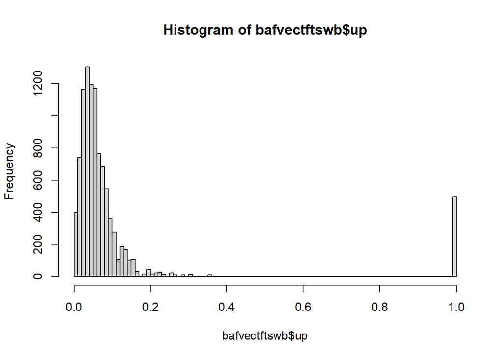

```r
#summary(bafvectftswb$up) # up
#sd(bafvectftswb$up)
#quantile(bafvectftswb$up, probs=c(0.025,0.975))
hist(bafvectftswb$up, breaks=100)
```

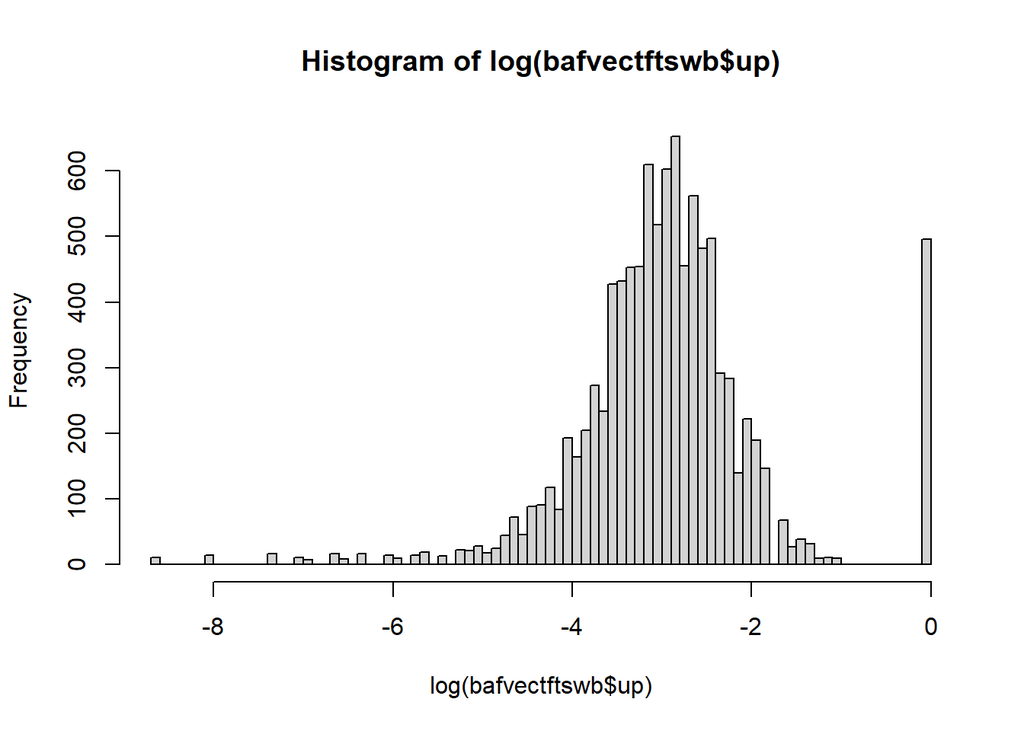

```r
hist(log(bafvectftswb$up), breaks=100)
```

```r
data.frame(
  mean=mean(bafvectftswb$up),
  median=median(bafvectftswb$up),
  sd=sd(bafvectftswb$up),
  twentyfifth=quantile(bafvectftswb$up, probs=c(0.25), names=F),
  seventyfifth=quantile(bafvectftswb$up, probs=c(0.75), names=F),
  lower=quantile(bafvectftswb$up, probs=c(0.025), names=F),
  upper=quantile(bafvectftswb$up, probs=0.975, names=F),
  min=min(bafvectftswb$up),
  max=max(bafvectftswb$up)
) |>
  kable(caption="summary stats of uptake rate bootstrap distribution")
```

summary stats of uptake rate bootstrap distribution

| mean | median | sd | twentyfifth | seventyfifth | lower | upper | min | max |
| --- | --- | --- | --- | --- | --- | --- | --- | --- |
| 0.1052565 | 0.0510351 | 0.2085252 | 0.0313364 | 0.0814058 | 0.0072928 | 1 | 0.0001774 | 1 |

### Summary of elimination rates via bootstrap estimates

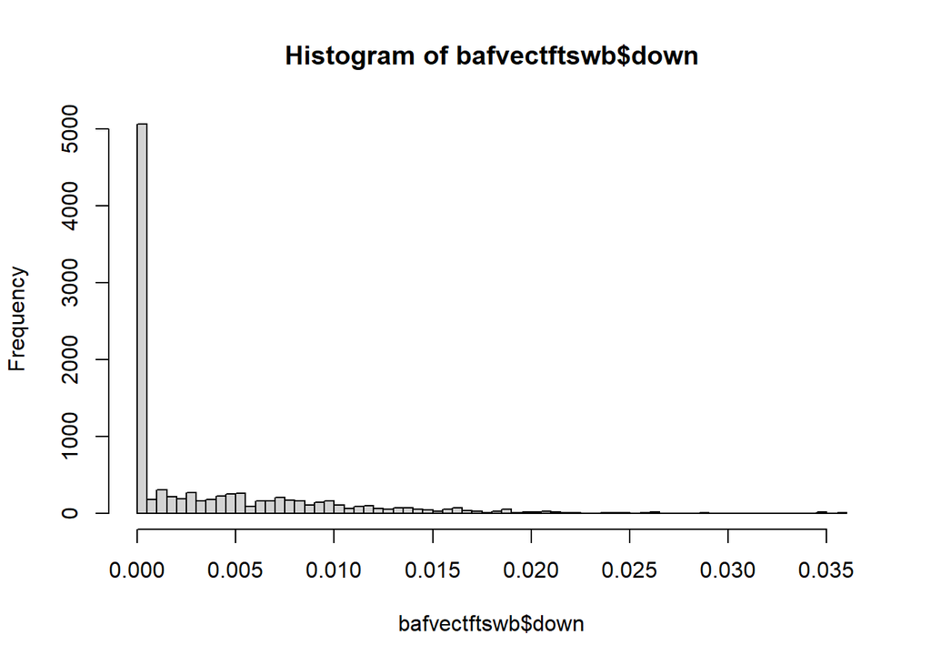

```r
#summary(bafvectftswb$down) # elim
#sd(bafvectftswb$down)
#quantile(bafvectftswb$down, probs=c(0.025,0.975))
hist(bafvectftswb$down, breaks=100)
```

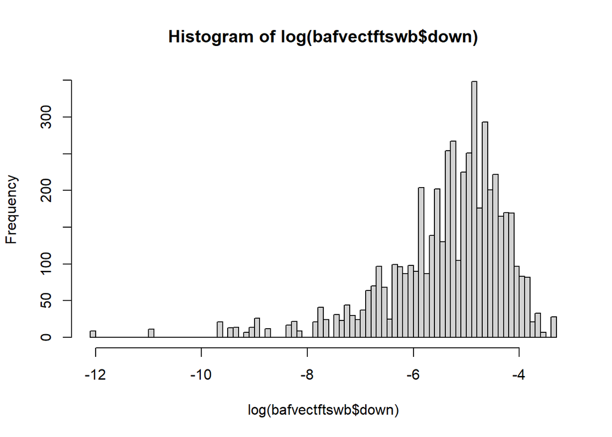

```r
hist(log(bafvectftswb$down), breaks=100)
```

```r
data.frame(
  mean=mean(bafvectftswb$down),
  median=median(bafvectftswb$down),
  sd=sd(bafvectftswb$down),
  twentyfifth=quantile(bafvectftswb$down, probs=c(0.25), names=F),
  seventyfifth=quantile(bafvectftswb$down, probs=c(0.75), names=F),
  lower=quantile(bafvectftswb$down, probs=c(0.025), names=F),
  upper=quantile(bafvectftswb$down, probs=0.975, names=F),
  min=min(bafvectftswb$down),
  max=max(bafvectftswb$down)
) |>
  kable(caption="summary stats of elimination rate bootstrap distribution")
```

summary stats of elimination rate bootstrap distribution

| mean | median | sd | twentyfifth | seventyfifth | lower | upper | min | max |
| --- | --- | --- | --- | --- | --- | --- | --- | --- |
| 0.0037349 | 0.0004132 | 0.0054949 | 0 | 0.0063578 | 0 | 0.0186277 | 0 | 0.0356228 |

### half-life using bootstrapped elimination rates

Median half-life of 8:2 FTS is 1677.4813362 with lower at 37.2106543 and upper at Inf.

```r
summary(log(2)/bafvectftswb$down)
```

```
##    Min. 1st Qu.  Median    Mean 3rd Qu.    Max.
##   19.46  109.02 1677.48     Inf     Inf     Inf
```

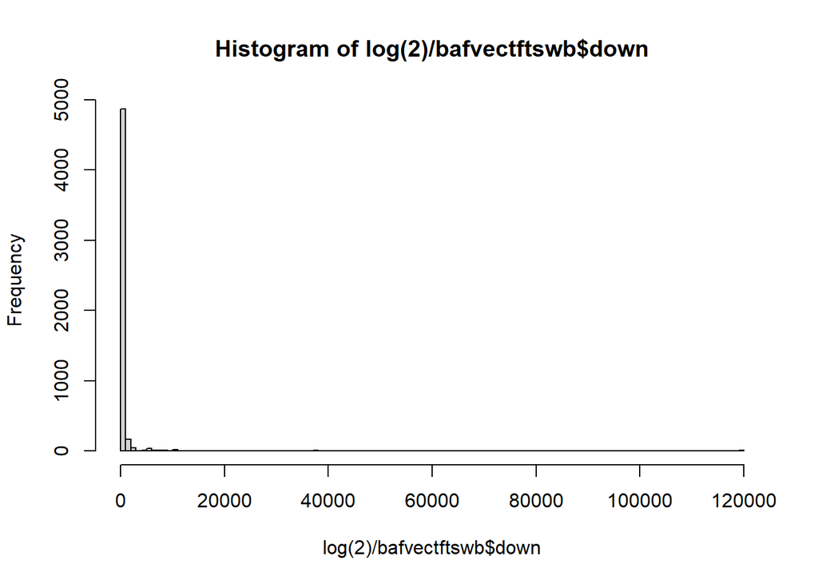

```r
hist(log(2)/bafvectftswb$down, breaks=100)
```

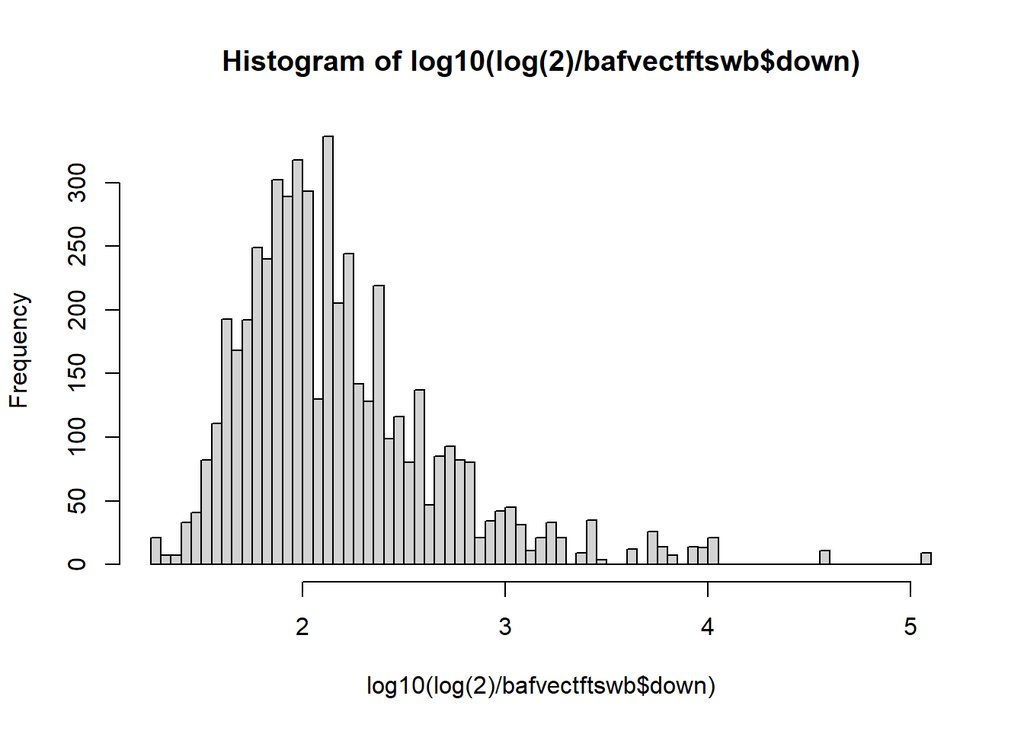

```r
hist(log10(log(2)/bafvectftswb$down), breaks=100)
```

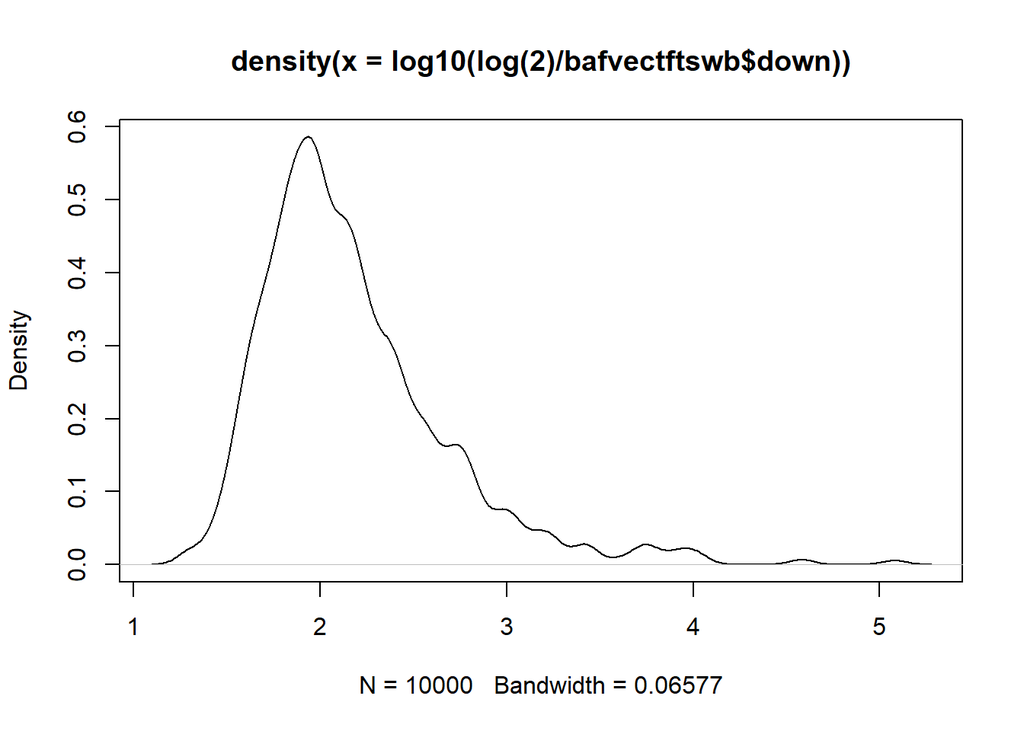

```r
plot(density(log10(log(2)/bafvectftswb$down)))
```

### Summary of TTC (uptake/elimination) and ln(TTC) resampling

```r
bafvectftswb <- data.frame(up=c(bafvectftswb$up), down=c(bafvectftswb$down))
bafvectftswb$baf <- bafvectftswb$up/bafvectftswb$down

data.frame(
  mean=mean(bafvectftswb$baf),
  median=median(bafvectftswb$baf),
  sd=sd(bafvectftswb$baf),
  twentyfifth=quantile(bafvectftswb$baf, probs=c(0.25), names=F),
  seventyfifth=quantile(bafvectftswb$baf, probs=c(0.75), names=F),
  lower=quantile(bafvectftswb$baf, probs=c(0.025), names=F),
  upper=quantile(bafvectftswb$baf, probs=0.975, names=F),
  min=min(bafvectftswb$baf),
  max=max(bafvectftswb$baf)
) |>
  kable(caption="summary stats of TTC bootstrap distribution")
```

summary stats of TTC bootstrap distribution

| mean | median | sd | twentyfifth | seventyfifth | lower | upper | min | max |
| --- | --- | --- | --- | --- | --- | --- | --- | --- |
| Inf | 269.265 | NaN | 9.089706 | Inf | 1.331189 | Inf | 0.0095008 | Inf |

```r
data.frame(
  mean=mean(log(bafvectftswb$baf)),
  median=median(log(bafvectftswb$baf)),
  sd=sd(log(bafvectftswb$baf)),
  twentyfifth=quantile(log(bafvectftswb$baf), probs=c(0.25), names=F),
  seventyfifth=quantile(log(bafvectftswb$baf), probs=c(0.75), names=F),
  lower=quantile(log(bafvectftswb$baf), probs=c(0.025), names=F),
  upper=quantile(log(bafvectftswb$baf), probs=0.975, names=F),
  min=min(log(bafvectftswb$baf)),
  max=max(log(bafvectftswb$baf))
) |>
  kable(caption="summary stats of log(TTC) bootstrap distribution")
```

summary stats of log(TTC) bootstrap distribution

| mean | median | sd | twentyfifth | seventyfifth | lower | upper | min | max |
| --- | --- | --- | --- | --- | --- | --- | --- | --- |
| Inf | 5.595631 | NaN | 2.207142 | Inf | 0.2860723 | Inf | -4.656383 | Inf |

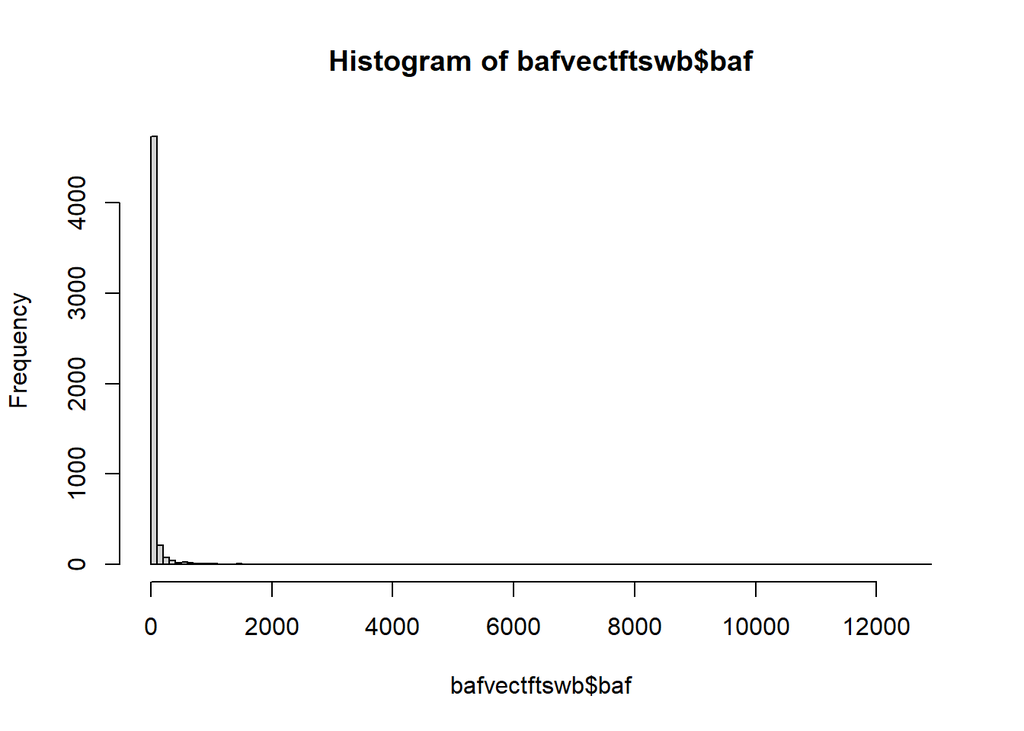

```r
hist(bafvectftswb$baf, breaks=100)
```

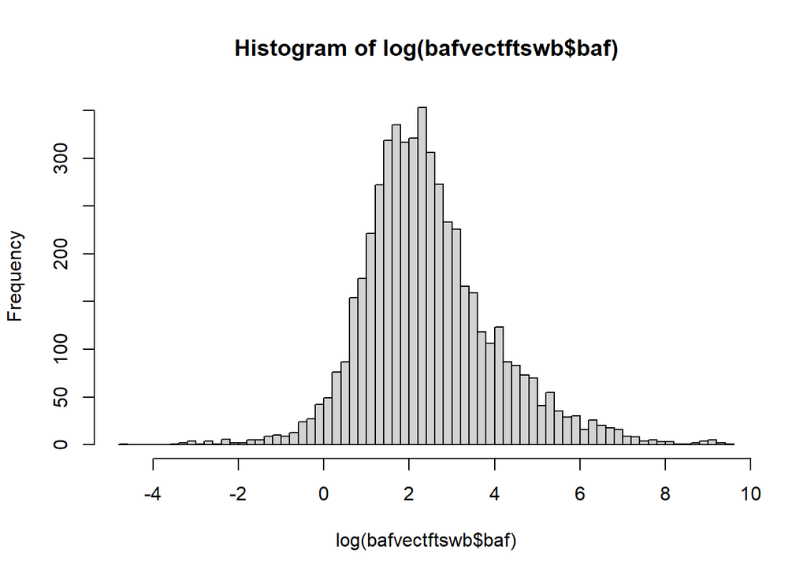

```r
hist(log(bafvectftswb$baf), breaks=100)
```

## 8:2 FTS estimate at 56 days constant exposure

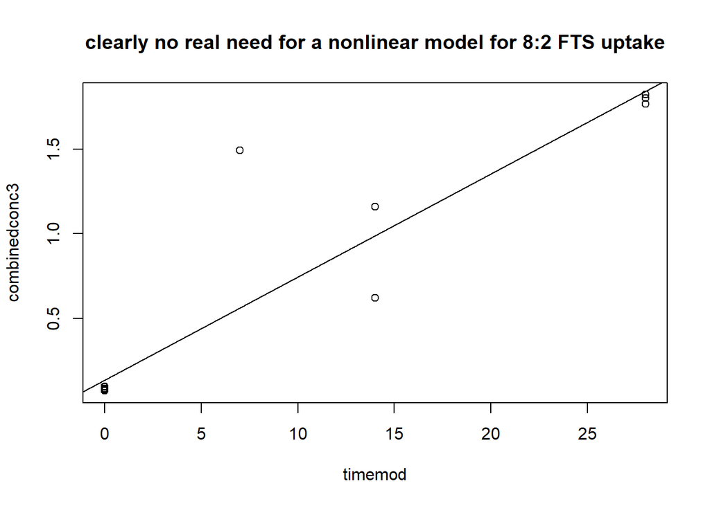

```r
plot(combinedconc3~timemod, data=ftswb|>filter(!is.na(combinedconc3))|>filter(timemod<=28), main="clearly no real need for a nonlinear model for 8:2 FTS uptake")
abline(lm(combinedconc3~timemod, data=ftswb|>filter(!is.na(combinedconc3))|>filter(timemod<=28)))
```

```r
summary(lm(combinedconc3~timemod, data=ftswb|>filter(!is.na(combinedconc3))|>filter(timemod<=28)))
```

```
##
## Call:
## lm(formula = combinedconc3 ~ timemod, data = filter(filter(ftswb,
##     !is.na(combinedconc3)), timemod <= 28))
##
## Residuals:
##      Min       1Q   Median       3Q      Max
## -0.36690 -0.05629 -0.05090 -0.03891  0.93149
##
## Coefficients:
##             Estimate Std. Error t value Pr(>|t|)
## (Intercept) 0.133670   0.071937   1.858   0.0816 .
## timemod     0.061008   0.005775  10.564 1.27e-08 ***
## ---
## Signif. codes:  0 '***' 0.001 '**' 0.01 '*' 0.05 '.' 0.1 ' ' 1
##
## Residual standard error: 0.2587 on 16 degrees of freedom
## Multiple R-squared:  0.8746, Adjusted R-squared:  0.8668
## F-statistic: 111.6 on 1 and 16 DF,  p-value: 1.273e-08
```

```r
ftswblm <- lm(combinedconc3~timemod, data=ftswb|>filter(!is.na(combinedconc3))|>filter(timemod<=28))
predict(ftswblm, newdata=data.frame(timemod=56), interval="confidence") |> kable(caption="linear model predicted whole animal 8:2 FTS concentration and 95% confidence intervals.")
```

linear model predicted whole animal 8:2 FTS concentration and 95% confidence intervals.

| fit | lwr | upr |
| --- | --- | --- |
| 3.550132 | 2.931828 | 4.168436 |

```r
# uptake rate is most likely 0.061




ftswbnlsbootday56 <- nlsBoot(nls(combinedconc3~background+((meanuptakediet*k01)/(V*(k01-k10)))*(exp(-k10*timemod)-exp(-k01*timemod)),
                        data=ftswb|>filter(!is.na(combinedconc3))|>filter(timemod<=28),
                        start=list(V=5, k10=0, k01=0.061), upper=c(10,1,1), lower=c(0,-2,-2),algorithm="port"))
ftswbnlsbootday56b <- nlsBoot(nls(combinedconc3~background+((meanuptakediet*k01)/(V*(k01-0.0009490)))*(exp(-0.0009490*timemod)-exp(-k01*timemod)),
                        data=ftswb|>filter(!is.na(combinedconc3))|>filter(timemod<=28),
                        start=list(V=5, k01=0.061), upper=c(10,1), lower=c(0,-2),algorithm="port"))
summary(ftswbnlsbootday56)
```

```
##
## ------
## Bootstrap statistics
##         Estimate Std. error
## V    9.460876243 1.30038437
## k10 -0.001654189 0.01056829
## k01  0.054331939 0.01854079
##
## ------
## Median of bootstrap estimates and percentile confidence intervals
##           Median        2.5%       97.5%
## V   10.000000000  4.95831753 10.00000000
## k10 -0.001174348 -0.02460857  0.02304054
## k01  0.054211801  0.02507630  0.09765654
```

```r
summary(ftswbnlsbootday56b)
```

```
##
## ------
## Bootstrap statistics
##       Estimate Std. error
## V   8.93882336 1.84398248
## k01 0.05328402 0.01655013
##
## ------
## Median of bootstrap estimates and percentile confidence intervals
##         Median       2.5%       97.5%
## V   9.83866055 4.23653417 10.00000000
## k01 0.05705965 0.01555301  0.07887269
```

```r
ftswbnlspredbootday56 <- data.frame(
  nlsBootPredict(
    ftswbnlsbootday56, newdata=data.frame(
      timemod=seq(0,56,by=1),
      background=ftswb$background[1],
      meanuptakediet=ftswb$meanuptakediet[1]#,
      #elimrate=ftswb$elimrate[1]
      #uptakeboot=ftswbnlsboot$estiboot[2,1]
      ), interval="confidence"))
ftswbnlspredbootday56$timemod <- c(seq(from=0,to=56,by=1))




ftswbnlspredbootday56b <- data.frame(
  nlsBootPredict(
    ftswbnlsbootday56b, newdata=data.frame(
      timemod=seq(0,56,by=1),
      background=ftswb$background[1],
      meanuptakediet=ftswb$meanuptakediet[1]#,
      #elimrate=ftswb$elimrate[1]
      #uptakeboot=ftswbnlsboot$estiboot[2,1]
      ), interval="confidence"))
ftswbnlspredbootday56b$timemod <- c(seq(from=0,to=56,by=1))
```

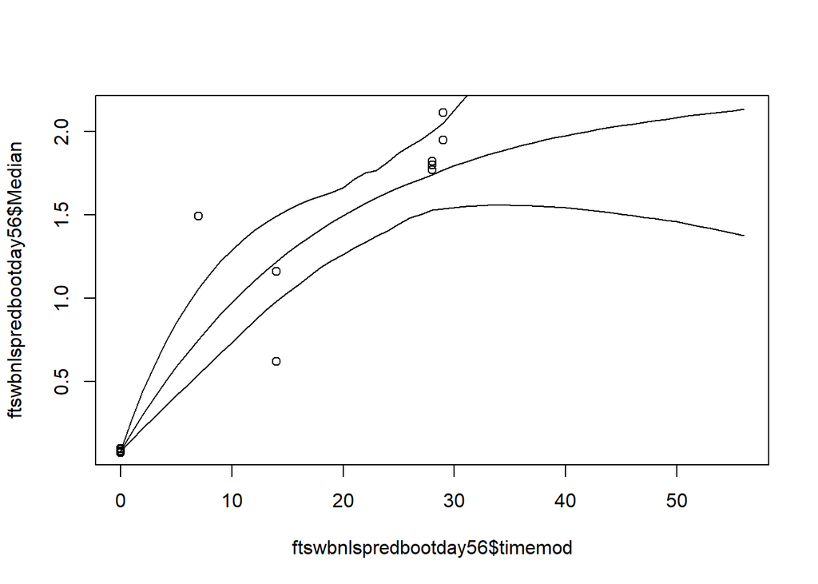

```r
plot(ftswbnlspredbootday56$Median~ftswbnlspredbootday56$timemod, type="l")
points(combinedconc3~timemod, data=ftswb|>filter(!is.na(combinedconc3))|>filter(timemod<=29))
points(ftswbnlspredbootday56$X2.5.~ftswbnlspredbootday56$timemod, type="l")
points(ftswbnlspredbootday56$X97.5.~ftswbnlspredbootday56$timemod, type="l")
```

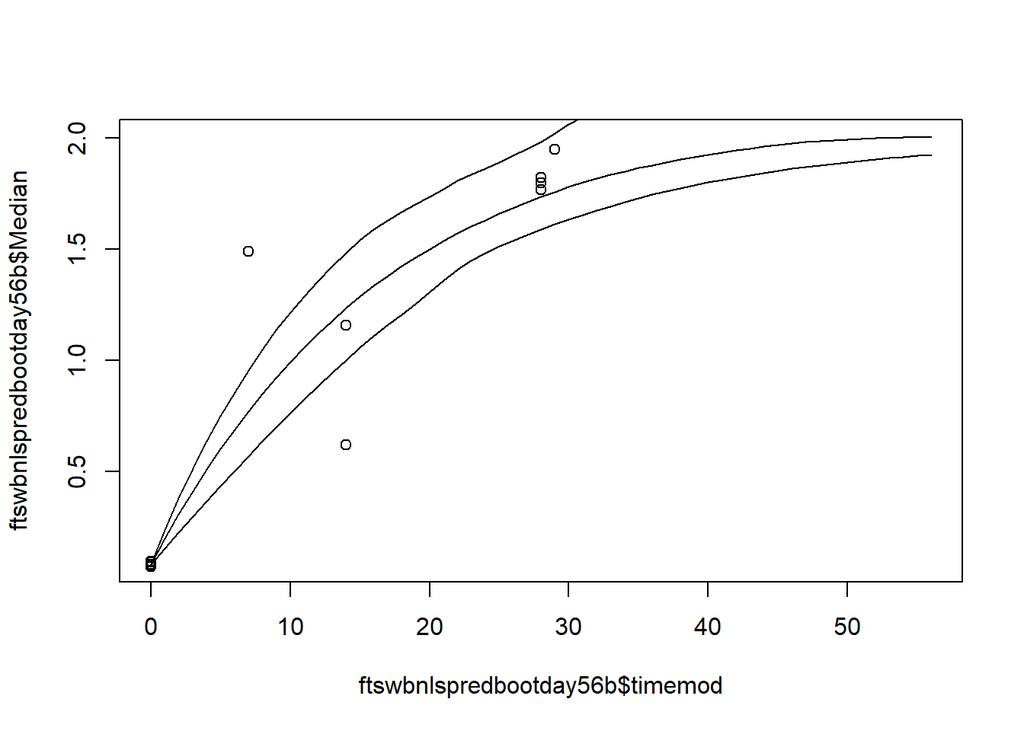

```r
plot(ftswbnlspredbootday56b$Median~ftswbnlspredbootday56b$timemod, type="l")
points(combinedconc3~timemod, data=ftswb|>filter(!is.na(combinedconc3))|>filter(timemod<=29))
points(ftswbnlspredbootday56b$X2.5.~ftswbnlspredbootday56b$timemod, type="l")
points(ftswbnlspredbootday56b$X97.5.~ftswbnlspredbootday56b$timemod, type="l")
```

```r
data.frame(
  day=ftswbnlspredbootday56[ftswbnlspredbootday56$timemod==56,4],
  medianestimate=ftswbnlspredbootday56[ftswbnlspredbootday56$timemod==56,1],
  lowerestimate=ftswbnlspredbootday56[ftswbnlspredbootday56$timemod==56,2],
  upperestimate=ftswbnlspredbootday56[ftswbnlspredbootday56$timemod==56,3]
  )|> kable(caption="Day 56 8:2 FTS bootstrap whole animal estimate using nonlinear model fit to data only during uptake period")
```

Day 56 8:2 FTS bootstrap whole animal estimate using nonlinear model fit to data only during uptake period

| day | medianestimate | lowerestimate | upperestimate |
| --- | --- | --- | --- |
| 56 | 2.132572 | 1.376953 | 4.563807 |

```r
data.frame(
  day=ftswbnlspredbootday56b[ftswbnlspredbootday56b$timemod==56,4],
  medianestimate=ftswbnlspredbootday56b[ftswbnlspredbootday56b$timemod==56,1],
  lowerestimate=ftswbnlspredbootday56b[ftswbnlspredbootday56b$timemod==56,2],
  upperestimate=ftswbnlspredbootday56b[ftswbnlspredbootday56b$timemod==56,3]
  )|> kable(caption="Day 56 8:2 FTS bootstrap whole animal estimate using nonlinear model fit to data only during uptake period")
```

Day 56 8:2 FTS bootstrap whole animal estimate using nonlinear model fit to data only during uptake period

| day | medianestimate | lowerestimate | upperestimate |
| --- | --- | --- | --- |
| 56 | 2.006099 | 1.92563 | 2.808032 |